# 01_06_corona_analysis

### 코로나 데이터 분석

### 학습 목표

- 코로나 데이터와 백신 접종률 데이터를 수집하여 지금까지 내용을 나라별로 분석해 본다.
- 데이터 분석을 통해 pandas에 대해 좀 더 깊이 알아본다.

### 데이터가 수집된 사이트

- bloomberg.com
  - https://www.bloomberg.com/graphics/covid-vaccine-tracker-global-distribution/
- 코로나 19(COVID-19) 실시간 상황판
  - https://coronaboard.kr/

```python
from IPython.display import display, Image
import os, warnings
import re
warnings.filterwarnings(action='ignore')
```

### 01 파일 불러오기

```python
os.listdir(os.getcwd())
```

```
['.ipynb_checkpoints',
 '01_02_Pandas알아보기_v10.pdf',
 '01_03_pandas_01.html',
 '01_03_pandas_01.ipynb',
 '01_03_pandas_01.pdf',
 '01_03_pandas_02_california.html',
 '01_03_pandas_02_california.ipynb',
 '01_03_pandas_02_california.pdf',
 '01_04_titanic_dataset.html',
 '01_04_titanic_dataset.ipynb',
 '01_04_titanic_dataset.pdf',
 '01_04_화장품관련키워드분석_ing.ipynb',
 '01_05_titanic_dataset_pandas_etc.html',
 '01_05_titanic_dataset_pandas_etc.ipynb',
 '01_05_titanic_dataset_pandas_etc.pdf',
 '01_06_corona_analysis.ipynb',
 '01_unit01_03_pandas.zip',
 '20210921_00_datamerge.csv',
 '20210921_00_datamerge.xlsx',
 'california_housing_test.csv',
 'california_housing_train.csv',
 'debug.log',
 'decision_first_model.csv',
 'pandas_신재용_0115.pdf',
 'team_12.csv',
 'team_12.xlsx',
 'yelp_pandas_허수경.pdf',
 '[REF]PyClass02_Bike_Model_Pandas.ipynb',
 '상위키워드리스트_20210108.xlsx']
```

```python
import pandas as pd

corona = pd.read_csv("20210921_00_datamerge.csv")
corona.shape
```

```
(178, 21)
```

### Learn 01. 보이지 않는 전체 내용을 표시해 보기

```python
print( pd.options.display.max_rows )
print( pd.options.display.max_columns )
```

```
500
500
```

```python
pd.options.display.max_columns = 500
pd.options.display.max_rows = 500
```

```python
corona.head()
```

|  | 국가명 | eng_code | 발생률 | 인구수 | 확진자_합계 | 백신접종 | 접종률(인구) | 발생률_순위 | 접종률_순위 | 확진자비율_전체인구 | 1차접종 | 2차접종 | 위중증 | 치명(%) | 완치(%) | 확진자1일 | 사망자합계 | 사망자1일 | 완치합계 | 완치1일 | 접종비율(일간) |
| --- | --- | --- | --- | --- | --- | --- | --- | --- | --- | --- | --- | --- | --- | --- | --- | --- | --- | --- | --- | --- | --- |
| 0 | 미국 | U.S. | 129632 | 331002651 | 42908619 | 385586020.0 | 60.2 | 13.0 | 46.0 | 0.129632 | 63.8 | 54.6 | 24327\n-523 | 1.6 | 75.8 | 41814.0 | 691992 | 430.0 | 32508846.0 | 25620.0 | 763444.0 |
| 1 | 인도 | India | 24277 | 1380004385 | 33483170 | 808389300.0 | 29.6 | 101.0 | 99.0 | 0.024263 | 43.7 | 14.5 | 8944 | 1.3 | 97.7 | 32085.0 | 445248 | 349.0 | 32715105.0 | 43938.0 | 9236028.0 |
| 2 | 브라질 | Brazil | 99924 | 212559417 | 21239783 | 222322660.0 | 53.9 | 27.0 | 62.0 | 0.099924 | 69.4 | 37.8 | 8318 | 2.8 | 95.5 | 9458.0 | 590786 | 239.0 | 20280294.0 | NaN | 1721039.0 |
| 3 | 영국 | U.K. | 109444 | 67886011 | 7429746 | 93002090.0 | 69.6 | 21.0 | 25.0 | 0.109444 | 72.7 | 66.5 | 1020 | 1.8 | 80.5 | 29007.0 | 135203 | 56.0 | 5981684.0 | 22993.0 | 83947.0 |
| 4 | 러시아 | Russia | 49986 | 145934462 | 7294672 | 87810616.0 | 29.9 | 77.0 | 97.0 | 0.049986 | 31.9 | 27.6 | 2300 | 2.7 | 89.3 | 19744.0 | 198996 | 778.0 | 6510674.0 | 11992.0 | 354749.0 |

```python
corona.info()
```

```
<class 'pandas.core.frame.DataFrame'>
RangeIndex: 178 entries, 0 to 177
Data columns (total 21 columns):
 #   Column      Non-Null Count  Dtype
---  ------      --------------  -----
 0   국가명         178 non-null    object
 1   eng_code    178 non-null    object
 2   발생률         178 non-null    int64
 3   인구수         178 non-null    int64
 4   확진자_합계      178 non-null    int64
 5   백신접종        178 non-null    float64
 6   접종률(인구)     178 non-null    float64
 7   발생률_순위      178 non-null    float64
 8   접종률_순위      178 non-null    float64
 9   확진자비율_전체인구  178 non-null    float64
 10  1차접종        178 non-null    float64
 11  2차접종        178 non-null    float64
 12  위중증         131 non-null    object
 13  치명(%)       178 non-null    object
 14  완치(%)       175 non-null    float64
 15  확진자1일       130 non-null    float64
 16  사망자합계       178 non-null    int64
 17  사망자1일       104 non-null    float64
 18  완치합계        175 non-null    float64
 19  완치1일        115 non-null    float64
 20  접종비율(일간)    178 non-null    float64
dtypes: float64(13), int64(4), object(4)
memory usage: 29.3+ KB
```

### 가설 : 백신 접종은 코로나 감염에 효과가 있다.

### 접종률(인구)와 발생률의 관계

```python
import seaborn as sns
import matplotlib.pyplot as plt
from matplotlib import font_manager, rc
import matplotlib
import platform
```

### 한글 표시하기

```python
path = "C:/Windows/Fonts/malgun.ttf"
if platform.system() == "Windows":
    font_name = font_manager.FontProperties(fname=path).get_name()
    rc('font', family=font_name)
elif platform.system()=="Darwin":
    rc('font', family='AppleGothic')
else:
    print("Unknown System")

matplotlib.rcParams['axes.unicode_minus'] = False
```

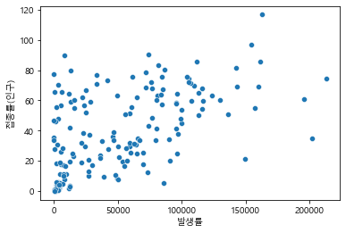

```python
sns.scatterplot(x='발생률', y='접종률(인구)', data=corona)
```

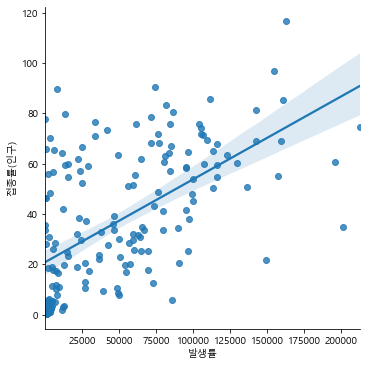

```python
sns.lmplot(x='발생률', y='접종률(인구)', data=corona)
```

```python
corona[['발생률', '접종률(인구)']].corr()
```

|  | 발생률 | 접종률(인구) |
| --- | --- | --- |
| 발생률 | 1.000000 | 0.582878 |
| 접종률(인구) | 0.582878 | 1.000000 |

### 확인 결과 나라별 백신 접종률과 인구당 확진자 비율은 0.582의 양의 상관관계를 갖는다.

- 백신을 접종하면 할수록 인구당 확진자 비율은 양의 관계로 늘어난다.

### 백신 발생률과 사망률(인구당)은 어떠한가?

```python
corona.head()
```

|  | 국가명 | eng_code | 발생률 | 인구수 | 확진자_합계 | 백신접종 | 접종률(인구) | 발생률_순위 | 접종률_순위 | 확진자비율_전체인구 | 1차접종 | 2차접종 | 위중증 | 치명(%) | 완치(%) | 확진자1일 | 사망자합계 | 사망자1일 | 완치합계 | 완치1일 | 접종비율(일간) |
| --- | --- | --- | --- | --- | --- | --- | --- | --- | --- | --- | --- | --- | --- | --- | --- | --- | --- | --- | --- | --- | --- |
| 0 | 미국 | U.S. | 129632 | 331002651 | 42908619 | 385586020.0 | 60.2 | 13.0 | 46.0 | 0.129632 | 63.8 | 54.6 | 24327\n-523 | 1.6 | 75.8 | 41814.0 | 691992 | 430.0 | 32508846.0 | 25620.0 | 763444.0 |
| 1 | 인도 | India | 24277 | 1380004385 | 33483170 | 808389300.0 | 29.6 | 101.0 | 99.0 | 0.024263 | 43.7 | 14.5 | 8944 | 1.3 | 97.7 | 32085.0 | 445248 | 349.0 | 32715105.0 | 43938.0 | 9236028.0 |
| 2 | 브라질 | Brazil | 99924 | 212559417 | 21239783 | 222322660.0 | 53.9 | 27.0 | 62.0 | 0.099924 | 69.4 | 37.8 | 8318 | 2.8 | 95.5 | 9458.0 | 590786 | 239.0 | 20280294.0 | NaN | 1721039.0 |
| 3 | 영국 | U.K. | 109444 | 67886011 | 7429746 | 93002090.0 | 69.6 | 21.0 | 25.0 | 0.109444 | 72.7 | 66.5 | 1020 | 1.8 | 80.5 | 29007.0 | 135203 | 56.0 | 5981684.0 | 22993.0 | 83947.0 |
| 4 | 러시아 | Russia | 49986 | 145934462 | 7294672 | 87810616.0 | 29.9 | 77.0 | 97.0 | 0.049986 | 31.9 | 27.6 | 2300 | 2.7 | 89.3 | 19744.0 | 198996 | 778.0 | 6510674.0 | 11992.0 | 354749.0 |

```python
### 사망률 = 사망자수/인구수
corona['사망률'] = corona['사망자합계'] /  corona['인구수']
corona
```

|  | 국가명 | eng_code | 발생률 | 인구수 | 확진자_합계 | 백신접종 | 접종률(인구) | 발생률_순위 | 접종률_순위 | 확진자비율_전체인구 | 1차접종 | 2차접종 | 위중증 | 치명(%) | 완치(%) | 확진자1일 | 사망자합계 | 사망자1일 | 완치합계 | 완치1일 | 접종비율(일간) | 사망률 |
| --- | --- | --- | --- | --- | --- | --- | --- | --- | --- | --- | --- | --- | --- | --- | --- | --- | --- | --- | --- | --- | --- | --- |
| 0 | 미국 | U.S. | 129632 | 331002651 | 42908619 | 3.855860e+08 | 60.2 | 13.0 | 46.0 | 0.129632 | 63.8 | 54.60 | 24327\n-523 | 1.6 | 75.8 | 41814.0 | 691992 | 430.0 | 32508846.0 | 25620.0 | 763444.0 | 0.002091 |
| 1 | 인도 | India | 24277 | 1380004385 | 33483170 | 8.083893e+08 | 29.6 | 101.0 | 99.0 | 0.024263 | 43.7 | 14.50 | 8944 | 1.3 | 97.7 | 32085.0 | 445248 | 349.0 | 32715105.0 | 43938.0 | 9236028.0 | 0.000323 |
| 2 | 브라질 | Brazil | 99924 | 212559417 | 21239783 | 2.223227e+08 | 53.9 | 27.0 | 62.0 | 0.099924 | 69.4 | 37.80 | 8318 | 2.8 | 95.5 | 9458.0 | 590786 | 239.0 | 20280294.0 | NaN | 1721039.0 | 0.002779 |
| 3 | 영국 | U.K. | 109444 | 67886011 | 7429746 | 9.300209e+07 | 69.6 | 21.0 | 25.0 | 0.109444 | 72.7 | 66.50 | 1020 | 1.8 | 80.5 | 29007.0 | 135203 | 56.0 | 5981684.0 | 22993.0 | 83947.0 | 0.001992 |
| 4 | 러시아 | Russia | 49986 | 145934462 | 7294672 | 8.781062e+07 | 29.9 | 77.0 | 97.0 | 0.049986 | 31.9 | 27.60 | 2300 | 2.7 | 89.3 | 19744.0 | 198996 | 778.0 | 6510674.0 | 11992.0 | 354749.0 | 0.001364 |
| 5 | 프랑스 | France | 106557 | 65273511 | 6955333 | 9.226241e+07 | 71.2 | 23.0 | 22.0 | 0.106557 | 76.7 | 72.70 | 1832\n-168 | 1.7 | 95.6 | 5814.0 | 116030 | 28.0 | 6649678.0 | 23192.0 | 242012.0 | 0.001778 |
| 6 | 터키 | Turkey | 81187 | 84339067 | 6847259 | 1.051146e+08 | 63.2 | 45.0 | 41.0 | 0.081187 | 63.3 | 50.50 | 633 | 0.9 | 92.5 | 26398.0 | 61574 | 213.0 | 6337070.0 | 27160.0 | 472820.0 | 0.000730 |
| 7 | 이란 | Iran | 64794 | 83992949 | 5442232 | 4.200386e+07 | 25.2 | 62.0 | 107.0 | 0.064794 | 34.1 | 16.60 | 6707\n-58 | 2.2 | 88.1 | 17397.0 | 117526 | 344.0 | 4792117.0 | 27119.0 | 1114116.0 | 0.001399 |
| 8 | 아르헨티나 | Argentina | 115923 | 45195774 | 5239232 | 4.901757e+07 | 54.5 | 16.0 | 61.0 | 0.115923 | 64.5 | 44.30 | 1496\n-20 | 2.2 | 97.3 | 622.0 | 114428 | 61.0 | 5096283.0 | 2932.0 | 290888.0 | 0.002532 |
| 9 | 콜롬비아 | Colombia | 97107 | 50882891 | 4941064 | 3.833164e+07 | 38.0 | 30.0 | 80.0 | 0.097107 | 49.3 | 31.70 | 542 | 2.5 | 96.7 | 1813.0 | 125895 | 35.0 | 4779552.0 | 1756.0 | 163255.0 | 0.002474 |
| 10 | 스페인 | Spain | 105434 | 46754778 | 4929546 | 6.909466e+07 | 74.3 | 24.0 | 18.0 | 0.105434 | 80.4 | 77.00 | 1028 | 1.7 | 94.0 | NaN | 85783 | NaN | 4633527.0 | NaN | 140084.0 | 0.001835 |
| 11 | 이탈리아 | Italy | 76678 | 60461826 | 4636111 | 8.237767e+07 | 68.2 | 49.0 | 29.0 | 0.076678 | 73.3 | 67.90 | 530\n+11 | 2.8 | 94.7 | 3836.0 | 130310 | 26.0 | 4392265.0 | 3314.0 | 219232.0 | 0.002155 |
| 12 | 인도네시아 | Indonesia | 15328 | 273523615 | 4192695 | 1.234548e+08 | 23.1 | 109.0 | 111.0 | 0.015328 | 29.4 | 16.80 | NaN | 3.4 | 95.3 | 1932.0 | 140634 | 166.0 | 3996125.0 | 6799.0 | 1381673.0 | 0.000514 |
| 13 | 독일 | Germany | 49569 | 83783942 | 4153067 | 1.054074e+08 | 63.4 | 79.0 | 40.0 | 0.049569 | 67.1 | 63.00 | 1217 | 2.3 | 93.9 | 6085.0 | 93592 | 34.0 | 3897800.0 | 15100.0 | 211307.0 | 0.001117 |
| 14 | 멕시코 | Mexico | 27686 | 128932753 | 3569677 | 9.527140e+07 | 37.3 | 95.0 | 81.0 | 0.027686 | 48.5 | 32.50 | 4798 | 7.6 | 81.9 | 4983.0 | 271503 | 200.0 | 2924904.0 | 8633.0 | 507287.0 | 0.002106 |
| 15 | 폴란드 | Poland | 76580 | 37846611 | 2898299 | 3.694714e+07 | 48.6 | 50.0 | 68.0 | 0.076580 | 51.7 | 50.70 | 113\n+2 | 2.6 | 91.8 | 364.0 | 75488 | NaN | 2659912.0 | 429.0 | 30007.0 | 0.001995 |
| 16 | 필리핀 | Philippines | 21770 | 109581078 | 2385616 | 4.051884e+07 | 18.9 | 105.0 | 121.0 | 0.021770 | 22.2 | 16.80 | 3170 | 1.5 | 91.0 | 18867.0 | 36934 | 146.0 | 2171832.0 | 20067.0 | 403560.0 | 0.000337 |
| 17 | 우크라이나 | Ukraine | 53749 | 43733762 | 2350646 | 1.655874e+07 | 19.8 | 75.0 | 119.0 | 0.053749 | 27.4 | 12.30 | 177 | 2.3 | 94.9 | 2265.0 | 54919 | 44.0 | 2231417.0 | 565.0 | 149085.0 | 0.001256 |
| 18 | 페루 | Peru | 65723 | 32971854 | 2167008 | 2.315884e+07 | 34.9 | 60.0 | 84.0 | 0.065723 | 42.0 | 27.90 | 1043\n+9 | 9.2 | NaN | 589.0 | 199006 | 30.0 | NaN | NaN | 225799.0 | 0.006036 |
| 19 | 말레이시아 | Malaysia | 64816 | 32365999 | 2097830 | 4.037506e+07 | 62.0 | 61.0 | 42.0 | 0.064816 | 67.3 | 56.20 | 1191\n+26 | 1.1 | 88.8 | 14954.0 | 23443 | 376.0 | 1863919.0 | 23469.0 | 269572.0 | 0.000724 |
| 20 | 네덜란드 | Netherlands | 115918 | 17134872 | 1986241 | 2.332039e+07 | 67.7 | 17.0 | 30.0 | 0.115918 | 70.0 | 63.40 | 208\n+11 | 0.9 | NaN | 1326.0 | 18123 | 9.0 | NaN | NaN | 40806.0 | 0.001058 |
| 21 | 이라크 | Iraq | 49187 | 40222493 | 1978412 | 6.672182e+06 | 8.5 | 80.0 | 138.0 | 0.049187 | 10.7 | 6.30 | 618\n+2 | 1.1 | 94.4 | 3192.0 | 21869 | 47.0 | 1867818.0 | 4878.0 | 306900.0 | 0.000544 |
| 22 | 체코 | Czech Republic | 157472 | 10708981 | 1686364 | 1.171255e+07 | 55.0 | 7.0 | 59.0 | 0.157472 | 56.7 | 55.30 | 28\n-1 | 1.8 | 97.9 | 182.0 | 30431 | 1.0 | 1650853.0 | 317.0 | 11672.0 | 0.002842 |
| 23 | 일본 | Japan | 13283 | 126476461 | 1680028 | 1.498825e+08 | 59.4 | 112.0 | 50.0 | 0.013283 | 65.5 | 53.30 | 1458\n-42 | 1.0 | 94.5 | 2218.0 | 17250 | 23.0 | 1586847.0 | 10277.0 | 1108541.0 | 0.000136 |
| 24 | 칠레 | Chile | 86196 | 19116201 | 1647746 | 3.078569e+07 | 80.6 | 38.0 | 9.0 | 0.086196 | 76.8 | 73.30 | 434\n-4 | 2.3 | 97.4 | 277.0 | 37367 | 8.0 | 1604353.0 | 419.0 | 83791.0 | 0.001955 |
| 25 | 캐나다 | Canada | 41687 | 37742154 | 1573359 | 5.506036e+07 | 73.4 | 86.0 | 19.0 | 0.041687 | 75.4 | 69.60 | 638 | 1.7 | 95.3 | 2032.0 | 27395 | 11.0 | 1499483.0 | 997.0 | 94377.0 | 0.000726 |
| 26 | 방글라데시 | Bangladesh | 9377 | 164689383 | 1544238 | 3.683279e+07 | 11.1 | 119.0 | 133.0 | 0.009377 | 13.3 | 8.80 | 1403 | 1.8 | 97.3 | 1555.0 | 27251 | 26.0 | 1503106.0 | 1565.0 | 363460.0 | 0.000165 |
| 27 | 태국 | Thailand | 21335 | 69799978 | 1489186 | 4.448566e+07 | 31.9 | 106.0 | 92.5 | 0.021335 | 40.8 | 20.50 | 4387 | 1.0 | 90.1 | 12709.0 | 15469 | 106.0 | 1341144.0 | 11125.0 | 632170.0 | 0.000222 |
| 28 | 이스라엘 | Israel | 142297 | 8655535 | 1231660 | 1.473209e+07 | 81.4 | 11.0 | 8.0 | 0.142297 | 67.0 | 61.60 | 714\n-12 | 0.6 | 93.2 | 9947.0 | 7541 | 30.0 | 1147578.0 | 17185.0 | 44039.0 | 0.000871 |
| 29 | 파키스탄 | Pakistan | 5550 | 220892340 | 1226008 | 7.298651e+07 | 17.8 | 130.0 | 123.0 | 0.005550 | 26.6 | 11.70 | 4840\n-124 | 2.2 | 92.6 | 2167.0 | 27246 | 40.0 | 1135038.0 | 2312.0 | 862739.0 | 0.000123 |

[output cut: 148 more lines]

### 가설 : 백신은 중증과 사망자 감소에 효과가 있다.

### 2-1 백신 접종률과 사망률의 관계는 어떠한가?

```python
corona[['사망률', '접종률(인구)']].corr()
```

|  | 사망률 | 접종률(인구) |
| --- | --- | --- |
| 사망률 | 1.000000 | 0.324012 |
| 접종률(인구) | 0.324012 | 1.000000 |

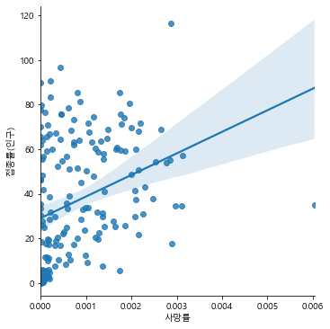

```python
sns.lmplot(x='사망률', y='접종률(인구)', data=corona)
```

### 백신 접종률과 사망률은 0.324의 양의 상관관계를 갖는다.

- 데이터로 봤을 때, 이 부분에 대한 확인이 필요해 보인다.

### 2-2 백신 접종률과 중증 감소의 관계는 어떠한가?

```python
corona.head(3)
```

|  | 국가명 | eng_code | 발생률 | 인구수 | 확진자_합계 | 백신접종 | 접종률(인구) | 발생률_순위 | 접종률_순위 | 확진자비율_전체인구 | 1차접종 | 2차접종 | 위중증 | 치명(%) | 완치(%) | 확진자1일 | 사망자합계 | 사망자1일 | 완치합계 | 완치1일 | 접종비율(일간) | 사망률 |
| --- | --- | --- | --- | --- | --- | --- | --- | --- | --- | --- | --- | --- | --- | --- | --- | --- | --- | --- | --- | --- | --- | --- |
| 0 | 미국 | U.S. | 129632 | 331002651 | 42908619 | 385586020.0 | 60.2 | 13.0 | 46.0 | 0.129632 | 63.8 | 54.6 | 24327\n-523 | 1.6 | 75.8 | 41814.0 | 691992 | 430.0 | 32508846.0 | 25620.0 | 763444.0 | 0.002091 |
| 1 | 인도 | India | 24277 | 1380004385 | 33483170 | 808389300.0 | 29.6 | 101.0 | 99.0 | 0.024263 | 43.7 | 14.5 | 8944 | 1.3 | 97.7 | 32085.0 | 445248 | 349.0 | 32715105.0 | 43938.0 | 9236028.0 | 0.000323 |
| 2 | 브라질 | Brazil | 99924 | 212559417 | 21239783 | 222322660.0 | 53.9 | 27.0 | 62.0 | 0.099924 | 69.4 | 37.8 | 8318 | 2.8 | 95.5 | 9458.0 | 590786 | 239.0 | 20280294.0 | NaN | 1721039.0 | 0.002779 |

```python
corona['위중증'].unique()
```

```
array(['24327\n-523', '8944', '8318', '1020', '2300', '1832\n-168', '633',
       '6707\n-58', '1496\n-20', '542', '1028', '530\n+11', nan, '1217',
       '4798', '113\n+2', '3170', '177', '1043\n+9', '1191\n+26',
       '208\n+11', '618\n+2', '28\n-1', '1458\n-42', '434\n-4', '638',
       '1403', '4387', '714\n-12', '4840\n-124', '218', '952\n+103', '43',
       '86\n-4', '776\n+3', '181\n-2', '221', '260\n+3', '45\n+4',
       '509\n+2', '503\n+42', '219\n+7', '380\n-5', '348', '200',
       '339\n-4', '5', '759', '489', '220', '391\n-5', '108', '37\n+1',
       '16\n-1', '60\n+1', '85\n+4', '11', '63\n-3', '515', '681',
       '22\n-1', '784\n-16', '166\n+4', '19\n-8', '90', '332\n-1',
       '63\n+3', '100\n+6', '192', '2', '109', '19\n+1', '21\n-3',
       '20\n+1', '131', '1', '23', '3', '1124', '36\n-2', '18', '32',
       '20', '12', '19', '42', '381', '45', '127\n-31', '19\n-4', '292',
       '152', '55\n-2', '21\n+3', '9', '7\n-1', '67', '8', '39', '10',
       '22', '24', '15', '7', '4', '6', '2\n+1', '22\n-2'], dtype=object)
```

### Learn02. Pandas 문자열 처리

- [].str.strip() : 앞뒤 공백을 제거
- [].str.lstrip() : 앞 공백을 제거
- [].str.rstrip() : 뒤 공백을 제거
- [].str.split('구분자', n=1, expand=True) : 구분자를 기준으로 n개로 나눈다. expand=True(여러컬럼), False(하나의 컬럼)

```python
corona[['위중증_수', '위중증_증감']] = corona['위중증'].str.split('\n', n=2, expand=True)
corona
```

|  | 국가명 | eng_code | 발생률 | 인구수 | 확진자_합계 | 백신접종 | 접종률(인구) | 발생률_순위 | 접종률_순위 | 확진자비율_전체인구 | 1차접종 | 2차접종 | 위중증 | 치명(%) | 완치(%) | 확진자1일 | 사망자합계 | 사망자1일 | 완치합계 | 완치1일 | 접종비율(일간) | 사망률 | 위중증_수 | 위중증_증감 |
| --- | --- | --- | --- | --- | --- | --- | --- | --- | --- | --- | --- | --- | --- | --- | --- | --- | --- | --- | --- | --- | --- | --- | --- | --- |
| 0 | 미국 | U.S. | 129632 | 331002651 | 42908619 | 3.855860e+08 | 60.2 | 13.0 | 46.0 | 0.129632 | 63.8 | 54.60 | 24327\n-523 | 1.6 | 75.8 | 41814.0 | 691992 | 430.0 | 32508846.0 | 25620.0 | 763444.0 | 0.002091 | 24327 | -523 |
| 1 | 인도 | India | 24277 | 1380004385 | 33483170 | 8.083893e+08 | 29.6 | 101.0 | 99.0 | 0.024263 | 43.7 | 14.50 | 8944 | 1.3 | 97.7 | 32085.0 | 445248 | 349.0 | 32715105.0 | 43938.0 | 9236028.0 | 0.000323 | 8944 | None |
| 2 | 브라질 | Brazil | 99924 | 212559417 | 21239783 | 2.223227e+08 | 53.9 | 27.0 | 62.0 | 0.099924 | 69.4 | 37.80 | 8318 | 2.8 | 95.5 | 9458.0 | 590786 | 239.0 | 20280294.0 | NaN | 1721039.0 | 0.002779 | 8318 | None |
| 3 | 영국 | U.K. | 109444 | 67886011 | 7429746 | 9.300209e+07 | 69.6 | 21.0 | 25.0 | 0.109444 | 72.7 | 66.50 | 1020 | 1.8 | 80.5 | 29007.0 | 135203 | 56.0 | 5981684.0 | 22993.0 | 83947.0 | 0.001992 | 1020 | None |
| 4 | 러시아 | Russia | 49986 | 145934462 | 7294672 | 8.781062e+07 | 29.9 | 77.0 | 97.0 | 0.049986 | 31.9 | 27.60 | 2300 | 2.7 | 89.3 | 19744.0 | 198996 | 778.0 | 6510674.0 | 11992.0 | 354749.0 | 0.001364 | 2300 | None |
| 5 | 프랑스 | France | 106557 | 65273511 | 6955333 | 9.226241e+07 | 71.2 | 23.0 | 22.0 | 0.106557 | 76.7 | 72.70 | 1832\n-168 | 1.7 | 95.6 | 5814.0 | 116030 | 28.0 | 6649678.0 | 23192.0 | 242012.0 | 0.001778 | 1832 | -168 |
| 6 | 터키 | Turkey | 81187 | 84339067 | 6847259 | 1.051146e+08 | 63.2 | 45.0 | 41.0 | 0.081187 | 63.3 | 50.50 | 633 | 0.9 | 92.5 | 26398.0 | 61574 | 213.0 | 6337070.0 | 27160.0 | 472820.0 | 0.000730 | 633 | None |
| 7 | 이란 | Iran | 64794 | 83992949 | 5442232 | 4.200386e+07 | 25.2 | 62.0 | 107.0 | 0.064794 | 34.1 | 16.60 | 6707\n-58 | 2.2 | 88.1 | 17397.0 | 117526 | 344.0 | 4792117.0 | 27119.0 | 1114116.0 | 0.001399 | 6707 | -58 |
| 8 | 아르헨티나 | Argentina | 115923 | 45195774 | 5239232 | 4.901757e+07 | 54.5 | 16.0 | 61.0 | 0.115923 | 64.5 | 44.30 | 1496\n-20 | 2.2 | 97.3 | 622.0 | 114428 | 61.0 | 5096283.0 | 2932.0 | 290888.0 | 0.002532 | 1496 | -20 |
| 9 | 콜롬비아 | Colombia | 97107 | 50882891 | 4941064 | 3.833164e+07 | 38.0 | 30.0 | 80.0 | 0.097107 | 49.3 | 31.70 | 542 | 2.5 | 96.7 | 1813.0 | 125895 | 35.0 | 4779552.0 | 1756.0 | 163255.0 | 0.002474 | 542 | None |
| 10 | 스페인 | Spain | 105434 | 46754778 | 4929546 | 6.909466e+07 | 74.3 | 24.0 | 18.0 | 0.105434 | 80.4 | 77.00 | 1028 | 1.7 | 94.0 | NaN | 85783 | NaN | 4633527.0 | NaN | 140084.0 | 0.001835 | 1028 | None |
| 11 | 이탈리아 | Italy | 76678 | 60461826 | 4636111 | 8.237767e+07 | 68.2 | 49.0 | 29.0 | 0.076678 | 73.3 | 67.90 | 530\n+11 | 2.8 | 94.7 | 3836.0 | 130310 | 26.0 | 4392265.0 | 3314.0 | 219232.0 | 0.002155 | 530 | +11 |
| 12 | 인도네시아 | Indonesia | 15328 | 273523615 | 4192695 | 1.234548e+08 | 23.1 | 109.0 | 111.0 | 0.015328 | 29.4 | 16.80 | NaN | 3.4 | 95.3 | 1932.0 | 140634 | 166.0 | 3996125.0 | 6799.0 | 1381673.0 | 0.000514 | NaN | NaN |
| 13 | 독일 | Germany | 49569 | 83783942 | 4153067 | 1.054074e+08 | 63.4 | 79.0 | 40.0 | 0.049569 | 67.1 | 63.00 | 1217 | 2.3 | 93.9 | 6085.0 | 93592 | 34.0 | 3897800.0 | 15100.0 | 211307.0 | 0.001117 | 1217 | None |
| 14 | 멕시코 | Mexico | 27686 | 128932753 | 3569677 | 9.527140e+07 | 37.3 | 95.0 | 81.0 | 0.027686 | 48.5 | 32.50 | 4798 | 7.6 | 81.9 | 4983.0 | 271503 | 200.0 | 2924904.0 | 8633.0 | 507287.0 | 0.002106 | 4798 | None |
| 15 | 폴란드 | Poland | 76580 | 37846611 | 2898299 | 3.694714e+07 | 48.6 | 50.0 | 68.0 | 0.076580 | 51.7 | 50.70 | 113\n+2 | 2.6 | 91.8 | 364.0 | 75488 | NaN | 2659912.0 | 429.0 | 30007.0 | 0.001995 | 113 | +2 |
| 16 | 필리핀 | Philippines | 21770 | 109581078 | 2385616 | 4.051884e+07 | 18.9 | 105.0 | 121.0 | 0.021770 | 22.2 | 16.80 | 3170 | 1.5 | 91.0 | 18867.0 | 36934 | 146.0 | 2171832.0 | 20067.0 | 403560.0 | 0.000337 | 3170 | None |
| 17 | 우크라이나 | Ukraine | 53749 | 43733762 | 2350646 | 1.655874e+07 | 19.8 | 75.0 | 119.0 | 0.053749 | 27.4 | 12.30 | 177 | 2.3 | 94.9 | 2265.0 | 54919 | 44.0 | 2231417.0 | 565.0 | 149085.0 | 0.001256 | 177 | None |
| 18 | 페루 | Peru | 65723 | 32971854 | 2167008 | 2.315884e+07 | 34.9 | 60.0 | 84.0 | 0.065723 | 42.0 | 27.90 | 1043\n+9 | 9.2 | NaN | 589.0 | 199006 | 30.0 | NaN | NaN | 225799.0 | 0.006036 | 1043 | +9 |
| 19 | 말레이시아 | Malaysia | 64816 | 32365999 | 2097830 | 4.037506e+07 | 62.0 | 61.0 | 42.0 | 0.064816 | 67.3 | 56.20 | 1191\n+26 | 1.1 | 88.8 | 14954.0 | 23443 | 376.0 | 1863919.0 | 23469.0 | 269572.0 | 0.000724 | 1191 | +26 |
| 20 | 네덜란드 | Netherlands | 115918 | 17134872 | 1986241 | 2.332039e+07 | 67.7 | 17.0 | 30.0 | 0.115918 | 70.0 | 63.40 | 208\n+11 | 0.9 | NaN | 1326.0 | 18123 | 9.0 | NaN | NaN | 40806.0 | 0.001058 | 208 | +11 |
| 21 | 이라크 | Iraq | 49187 | 40222493 | 1978412 | 6.672182e+06 | 8.5 | 80.0 | 138.0 | 0.049187 | 10.7 | 6.30 | 618\n+2 | 1.1 | 94.4 | 3192.0 | 21869 | 47.0 | 1867818.0 | 4878.0 | 306900.0 | 0.000544 | 618 | +2 |
| 22 | 체코 | Czech Republic | 157472 | 10708981 | 1686364 | 1.171255e+07 | 55.0 | 7.0 | 59.0 | 0.157472 | 56.7 | 55.30 | 28\n-1 | 1.8 | 97.9 | 182.0 | 30431 | 1.0 | 1650853.0 | 317.0 | 11672.0 | 0.002842 | 28 | -1 |
| 23 | 일본 | Japan | 13283 | 126476461 | 1680028 | 1.498825e+08 | 59.4 | 112.0 | 50.0 | 0.013283 | 65.5 | 53.30 | 1458\n-42 | 1.0 | 94.5 | 2218.0 | 17250 | 23.0 | 1586847.0 | 10277.0 | 1108541.0 | 0.000136 | 1458 | -42 |
| 24 | 칠레 | Chile | 86196 | 19116201 | 1647746 | 3.078569e+07 | 80.6 | 38.0 | 9.0 | 0.086196 | 76.8 | 73.30 | 434\n-4 | 2.3 | 97.4 | 277.0 | 37367 | 8.0 | 1604353.0 | 419.0 | 83791.0 | 0.001955 | 434 | -4 |
| 25 | 캐나다 | Canada | 41687 | 37742154 | 1573359 | 5.506036e+07 | 73.4 | 86.0 | 19.0 | 0.041687 | 75.4 | 69.60 | 638 | 1.7 | 95.3 | 2032.0 | 27395 | 11.0 | 1499483.0 | 997.0 | 94377.0 | 0.000726 | 638 | None |
| 26 | 방글라데시 | Bangladesh | 9377 | 164689383 | 1544238 | 3.683279e+07 | 11.1 | 119.0 | 133.0 | 0.009377 | 13.3 | 8.80 | 1403 | 1.8 | 97.3 | 1555.0 | 27251 | 26.0 | 1503106.0 | 1565.0 | 363460.0 | 0.000165 | 1403 | None |
| 27 | 태국 | Thailand | 21335 | 69799978 | 1489186 | 4.448566e+07 | 31.9 | 106.0 | 92.5 | 0.021335 | 40.8 | 20.50 | 4387 | 1.0 | 90.1 | 12709.0 | 15469 | 106.0 | 1341144.0 | 11125.0 | 632170.0 | 0.000222 | 4387 | None |
| 28 | 이스라엘 | Israel | 142297 | 8655535 | 1231660 | 1.473209e+07 | 81.4 | 11.0 | 8.0 | 0.142297 | 67.0 | 61.60 | 714\n-12 | 0.6 | 93.2 | 9947.0 | 7541 | 30.0 | 1147578.0 | 17185.0 | 44039.0 | 0.000871 | 714 | -12 |
| 29 | 파키스탄 | Pakistan | 5550 | 220892340 | 1226008 | 7.298651e+07 | 17.8 | 130.0 | 123.0 | 0.005550 | 26.6 | 11.70 | 4840\n-124 | 2.2 | 92.6 | 2167.0 | 27246 | 40.0 | 1135038.0 | 2312.0 | 862739.0 | 0.000123 | 4840 | -124 |

[output cut: 148 more lines]

```python
### 사망률 = 사망자수/인구수
corona['위중증률'] = corona['위중증_수'] /  corona['인구수']
corona
```

[output not shown]

[output cut: 20 more lines]

[output not shown]

### 에러 발생

- TypeError: unsupported operand type(s) for /: 'str' and 'int'

### Learn 03. 데이터 타입 변경하기

- [].astype(dtype) : 모든 열의 데이터 타입을 변경
- [].astype( {'컬럼명':dtype} ) : 특정 컬럼의 데이터 타입을 변경
  - str, int, float, category 등
  - int8, int16, int32, int64와 같이 변경 가능

```python
corona.info()
```

```
<class 'pandas.core.frame.DataFrame'>
RangeIndex: 178 entries, 0 to 177
Data columns (total 24 columns):
 #   Column      Non-Null Count  Dtype
---  ------      --------------  -----
 0   국가명         178 non-null    object
 1   eng_code    178 non-null    object
 2   발생률         178 non-null    int64
 3   인구수         178 non-null    int64
 4   확진자_합계      178 non-null    int64
 5   백신접종        178 non-null    float64
 6   접종률(인구)     178 non-null    float64
 7   발생률_순위      178 non-null    float64
 8   접종률_순위      178 non-null    float64
 9   확진자비율_전체인구  178 non-null    float64
```

[output cut: 16 more lines]

```python
corona['위중증_수'] = corona['위중증_수'].astype('int64')
```

[output not shown]

### 에러 발생

- ValueError: cannot convert float NaN to integer

```python
corona['위중증_수'].unique()
```

```
array(['24327', '8944', '8318', '1020', '2300', '1832', '633', '6707',
       '1496', '542', '1028', '530', nan, '1217', '4798', '113', '3170',
       '177', '1043', '1191', '208', '618', '28', '1458', '434', '638',
       '1403', '4387', '714', '4840', '218', '952', '43', '86', '776',
       '181', '221', '260', '45', '509', '503', '219', '380', '348',
       '200', '339', '5', '759', '489', '220', '391', '108', '37', '16',
       '60', '85', '11', '63', '515', '681', '22', '784', '166', '19',
       '90', '332', '100', '192', '2', '109', '21', '20', '131', '1',
       '23', '3', '1124', '36', '18', '32', '12', '42', '381', '127',
       '292', '152', '55', '9', '7', '67', '8', '39', '10', '24', '15',
       '4', '6'], dtype=object)
```

### Learn 04. 어떻게 NaN을 체크할 것인가?

```python
corona.info()
```

```
<class 'pandas.core.frame.DataFrame'>
RangeIndex: 178 entries, 0 to 177
Data columns (total 24 columns):
 #   Column      Non-Null Count  Dtype
---  ------      --------------  -----
 0   국가명         178 non-null    object
 1   eng_code    178 non-null    object
 2   발생률         178 non-null    int64
 3   인구수         178 non-null    int64
 4   확진자_합계      178 non-null    int64
 5   백신접종        178 non-null    float64
 6   접종률(인구)     178 non-null    float64
 7   발생률_순위      178 non-null    float64
 8   접종률_순위      178 non-null    float64
 9   확진자비율_전체인구  178 non-null    float64
```

[output cut: 16 more lines]

### 위중증_수가 isnull()인 것을 살펴보기

```python
corona[  corona['위중증_수'].isnull() ]
```

|  | 국가명 | eng_code | 발생률 | 인구수 | 확진자_합계 | 백신접종 | 접종률(인구) | 발생률_순위 | 접종률_순위 | 확진자비율_전체인구 | 1차접종 | 2차접종 | 위중증 | 치명(%) | 완치(%) | 확진자1일 | 사망자합계 | 사망자1일 | 완치합계 | 완치1일 | 접종비율(일간) | 사망률 | 위중증_수 | 위중증_증감 |
| --- | --- | --- | --- | --- | --- | --- | --- | --- | --- | --- | --- | --- | --- | --- | --- | --- | --- | --- | --- | --- | --- | --- | --- | --- |
| 12 | 인도네시아 | Indonesia | 15328 | 273523615 | 4192695 | 1.234548e+08 | 23.1 | 109.0 | 111.0 | 0.015328 | 29.4 | 16.80 | NaN | 3.4 | 95.3 | 1932.0 | 140634 | 166.0 | 3996125.0 | 6799.0 | 1381673.0 | 0.000514 | NaN | NaN |
| 41 | 네팔 | Nepal | 26960 | 29136808 | 785541 | 1.178218e+07 | 20.7 | 97.0 | 115.0 | 0.026960 | 21.8 | 19.50 | NaN | 1.4 | 95.8 | 975.0 | 11048 | 8.0 | 752170.0 | 2957.0 | 120269.0 | 0.000379 | NaN | NaN |
| 42 | 아랍에미레이트 | UAE | 74113 | 9890402 | 733003 | 1.944587e+07 | 90.5 | 52.0 | 3.0 | 0.074113 | 84.5 | 74.50 | NaN | 0.3 | 98.9 | 313.0 | 2077 | 2.0 | 724855.0 | 409.0 | 71904.0 | 0.000210 | NaN | NaN |
| 45 | 베트남 | Vietnam | 7148 | 97338579 | 695744 | 3.355536e+07 | 17.4 | 125.0 | 125.5 | 0.007148 | 28.2 | 6.60 | NaN | 2.5 | 66.7 | 8681.0 | 17305 | 215.0 | 464326.0 | 6821.0 | 920967.0 | 0.000178 | NaN | NaN |
| 48 | 조지아 | Georgia | 149386 | 3989167 | 595926 | 1.610309e+06 | 21.6 | 9.0 | 114.0 | 0.149386 | 25.1 | 18.10 | NaN | 1.4 | 94.6 | 662.0 | 8575 | 34.0 | 563530.0 | 3534.0 | 30838.0 | 0.002150 | NaN | NaN |
| 51 | 벨라루스 | Belarus | 54858 | 9449323 | 518369 | 3.206505e+06 | 16.9 | 74.0 | 127.0 | 0.054858 | 18.5 | 15.40 | NaN | 0.8 | 97.3 | 1941.0 | 4016 | 12.0 | 504561.0 | 1295.0 | 17321.0 | 0.000425 | NaN | NaN |
| 54 | 스리랑카 | Sri Lanka | 23560 | 21413249 | 504491 | 2.480400e+07 | 56.9 | 102.0 | 55.0 | 0.023560 | 62.9 | 50.30 | NaN | 2.4 | 85.6 | 1733.0 | 12125 | 103.0 | 432038.0 | 1002.0 | 114450.0 | 0.000566 | NaN | NaN |
| 57 | 아제르바이잔 | Azerbaijan | 46623 | 10139177 | 472719 | 7.806235e+06 | 39.1 | 82.0 | 78.0 | 0.046623 | 45.8 | 32.40 | NaN | 1.3 | 91.8 | NaN | 6305 | NaN | 434095.0 | NaN | 53555.0 | 0.000622 | NaN | NaN |
| 60 | 미얀마 | Myanmar | 8208 | 54409800 | 446573 | 8.184418e+06 | 7.7 | 121.0 | 139.0 | 0.008208 | 9.4 | 6.10 | NaN | 3.8 | 89.2 | 1702.0 | 17073 | 57.0 | 398220.0 | 2365.0 | 83945.0 | 0.000314 | NaN | NaN |
| 70 | 리비아 | Libya | 48321 | 6871292 | 332026 | 1.393696e+06 | 10.6 | 81.0 | 134.0 | 0.048321 | 19.0 | 2.10 | NaN | 1.4 | 74.7 | 1081.0 | 4517 | 16.0 | 248119.0 | 1310.0 | 22693.0 | 0.000657 | NaN | NaN |
| 79 | 아르메니아 | Armenia | 85697 | 2963243 | 253942 | 3.357210e+05 | 5.7 | 39.0 | 143.0 | 0.085697 | 7.3 | 4.10 | NaN | 2.0 | 93.2 | 342.0 | 5143 | 12.0 | 236578.0 | 490.0 | 5399.0 | 0.001736 | NaN | NaN |
| 85 | 북마케도니아 | North Macedonia | 89717 | 2083374 | 186914 | 1.435392e+06 | 34.5 | 37.0 | 86.0 | 0.089717 | 36.9 | 32.10 | NaN | 3.5 | 89.6 | 365.0 | 6460 | 23.0 | 167402.0 | 551.0 | 17806.0 | 0.003101 | NaN | NaN |
| 102 | 코소보 | Kosovo | 59381 | 1810463 | 107507 | 1.147803e+06 | 31.9 | 69.0 | 92.5 | 0.059381 | 40.1 | 23.60 | NaN | 2.1 | 98.0 | NaN | 2269 | NaN | 105323.0 | NaN | 18867.0 | 0.001253 | NaN | NaN |
| 103 | 캄보디아 | Cambodia | 6263 | 16718965 | 104716 | 2.161264e+07 | 65.5 | 128.0 | 34.0 | 0.006263 | 70.4 | 61.30 | NaN | 2.0 | 93.3 | 622.0 | 2123 | 14.0 | 97700.0 | 473.0 | 266799.0 | 0.000127 | NaN | NaN |
| 105 | 중국 | Mainland China | 67 | 1439323776 | 95738 | 2.174043e+09 | 77.6 | 176.0 | 12.0 | 0.000067 | 78.5 | 72.30 | NaN | 4.8 | 94.2 | 49.0 | 4636 | NaN | 90160.0 | 34.0 | 4494714.0 | 0.000003 | NaN | NaN |
| 115 | 코트디부아르 | Ivory Coast | 2237 | 26378274 | 59020 | 1.698973e+06 | 3.2 | 152.0 | 154.0 | 0.002237 | 4.5 | 1.00 | NaN | 1.0 | 96.0 | 131.0 | 566 | 5.0 | 56688.0 | 97.0 | 49953.0 | 0.000021 | NaN | NaN |
| 116 | 콩고민주공화국 | DR Congo | 630 | 89561403 | 56387 | 1.200620e+05 | 0.1 | 170.0 | 178.0 | 0.000630 | 0.1 | 0.05 | NaN | 1.9 | 54.7 | NaN | 1068 | NaN | 30858.0 | NaN | 1274.0 | 0.000012 | NaN | NaN |
| 121 | 수단 | Sudan | 868 | 43849260 | 38053 | 1.423327e+06 | 1.6 | 164.0 | 161.0 | 0.000868 | 1.5 | 1.20 | NaN | 7.6 | 83.9 | 53.0 | 2879 | 4.0 | 31940.0 | 24.0 | 50607.0 | 0.000066 | NaN | NaN |
| 128 | 토고 | Togo | 2971 | 8278724 | 24599 | 6.519410e+05 | 4.0 | 145.0 | 150.0 | 0.002971 | 5.1 | 2.90 | NaN | 0.9 | 83.0 | 80.0 | 213 | NaN | 20426.0 | 261.0 | 6848.0 | 0.000026 | NaN | NaN |
| 130 | 세이셸 | Seychelles | 212950 | 98347 | 20943 | 1.434900e+05 | 74.7 | 1.0 | 17.0 | 0.212950 | 77.4 | 72.60 | NaN | 0.5 | 96.7 | NaN | 114 | NaN | 20245.0 | NaN | 158.0 | 0.001159 | NaN | NaN |
| 132 | 라오스 | Laos | 2637 | 7275560 | 19185 | 4.402770e+06 | 30.7 | 149.0 | 96.0 | 0.002637 | 37.0 | 26.00 | NaN | 0.1 | 29.0 | NaN | 16 | NaN | 5568.0 | NaN | 9906.0 | 0.000002 | NaN | NaN |
| 133 | 동티모르 | Timor-Leste | 14455 | 1318445 | 19058 | 6.433240e+05 | 24.9 | 110.0 | 109.0 | 0.014455 | 31.6 | 18.10 | NaN | 0.6 | 91.2 | 25.0 | 105 | 1.0 | 17381.0 | 127.0 | 8284.0 | 0.000080 | NaN | NaN |
| 134 | 소말리아 | Somalia | 1196 | 15893222 | 19004 | 3.513050e+05 | 1.2 | 160.0 | 166.5 | 0.001196 | 1.5 | 0.80 | NaN | 5.6 | 48.4 | NaN | 1063 | NaN | 9191.0 | NaN | 3949.0 | 0.000067 | NaN | NaN |
| 137 | 타지키스탄 | Tajikistan | 1791 | 9537645 | 17084 | 3.446777e+06 | 18.5 | 155.0 | 122.0 | 0.001791 | 23.3 | 13.80 | NaN | 0.7 | 99.3 | NaN | 124 | NaN | 16960.0 | NaN | 54448.0 | 0.000013 | NaN | NaN |
| 138 | 대만 | Taiwan | 678 | 23816775 | 16147 | 1.317184e+07 | 27.9 | 168.0 | 102.0 | 0.000678 | 49.1 | 6.70 | NaN | 5.2 | 85.1 | 6.0 | 840 | NaN | 13742.0 | NaN | 144395.0 | 0.000035 | NaN | NaN |
| 141 | 말리 | Mali | 744 | 20250833 | 15068 | 3.705290e+05 | 1.0 | 167.0 | 168.0 | 0.000744 | 1.5 | 0.50 | NaN | 3.6 | 94.4 | 8.0 | 545 | NaN | 14218.0 | 3.0 | 3768.0 | 0.000027 | NaN | NaN |
| 142 | 모리셔스 | Mauritius | 11328 | 1271768 | 14406 | 1.625865e+06 | 64.2 | 118.0 | 37.0 | 0.011328 | 66.5 | 61.80 | NaN | 0.4 | 12.9 | 163.0 | 54 | 4.0 | 1854.0 | NaN | 5742.0 | 0.000042 | NaN | NaN |
| 143 | 레소토 | Lesotho | 6720 | 2142249 | 14395 | 2.017950e+05 | 4.9 | 126.0 | 147.0 | 0.006720 | 2.0 | -999.00 | NaN | 2.8 | 47.4 | NaN | 403 | NaN | 6830.0 | NaN | 24504.0 | 0.000188 | NaN | NaN |
| 144 | 부르키나파소 | Burkina Faso | 672 | 20903273 | 14041 | 1.661600e+05 | 0.4 | 169.0 | 175.0 | 0.000672 | 0.8 | 0.50 | NaN | 1.2 | 97.6 | NaN | 172 | NaN | 13697.0 | NaN | 4780.0 | 0.000008 | NaN | NaN |
| 145 | 콩고공화국 | Republic of the Congo | 2483 | 5518087 | 13701 | 3.192310e+05 | 3.5 | 150.0 | 152.0 | 0.002483 | 4.5 | 2.50 | NaN | 1.3 | 90.7 | NaN | 183 | NaN | 12421.0 | NaN | 1609.0 | 0.000033 | NaN | NaN |
| 146 | 니카라과 | Nicaragua | 1966 | 6624554 | 13025 | 7.691050e+05 | 5.9 | 154.0 | 142.0 | 0.001966 | 7.5 | 4.30 | NaN | 1.6 | 32.4 | NaN | 202 | NaN | 4225.0 | NaN | 6771.0 | 0.000030 | NaN | NaN |
| 147 | 홍콩 | Hong Kong | 1623 | 7496981 | 12165 | 8.380084e+06 | 55.7 | 157.0 | 57.0 | 0.001623 | 58.6 | 52.90 | NaN | 1.8 | 97.6 | 5.0 | 213 | NaN | 11872.0 | 3.0 | 32605.0 | 0.000028 | NaN | NaN |
| 148 | 지부티 | Djibouti | 12186 | 988000 | 12040 | 6.601000e+04 | 3.1 | 115.0 | 155.0 | 0.012186 | 3.7 | 2.40 | NaN | 1.3 | 97.4 | 80.0 | 159 | 2.0 | 11725.0 | 37.0 | 215.0 | 0.000161 | NaN | NaN |
| 149 | 남수단 | South Sudan | 1055 | 11193725 | 11814 | 6.710900e+04 | 0.3 | 162.0 | 176.5 | 0.001055 | 0.4 | 0.10 | NaN | 1.0 | 94.8 | 9.0 | 121 | NaN | 11195.0 | NaN | 1035.0 | 0.000011 | NaN | NaN |
| 155 | 바베이도스 | Barbados | 22712 | 287375 | 6527 | 2.210000e+05 | 38.5 | 103.0 | 79.0 | 0.022712 | 43.2 | 33.80 | NaN | 0.9 | 86.3 | 169.0 | 58 | 1.0 | 5632.0 | 266.0 | 1245.0 | 0.000202 | NaN | NaN |
| 156 | 시에라리온 | Sierra Leone | 801 | 7976983 | 6392 | 2.211100e+05 | 1.4 | 166.0 | 164.0 | 0.000801 | 2.3 | 0.50 | NaN | 1.9 | 68.5 | NaN | 121 | NaN | 4376.0 | 2.0 | 2296.0 | 0.000015 | NaN | NaN |
| 158 | 니제르 | Niger | 246 | 24206644 | 5957 | 6.218530e+05 | 1.3 | 174.0 | 165.0 | 0.000246 | 1.7 | 0.40 | NaN | 3.4 | 95.5 | NaN | 201 | NaN | 5689.0 | NaN | 9294.0 | 0.000008 | NaN | NaN |
| 163 | 차드 | Chad | 306 | 16425864 | 5029 | 1.047070e+05 | 0.3 | 172.0 | 176.5 | 0.000306 | 0.5 | 0.10 | NaN | 3.5 | 96.2 | 3.0 | 174 | NaN | 4837.0 | NaN | 2880.0 | 0.000011 | NaN | NaN |
| 165 | 코모로 | Comoros | 4722 | 869601 | 4106 | 3.343690e+05 | 19.1 | 133.0 | 120.0 | 0.004722 | 20.0 | 18.30 | NaN | 3.6 | 96.0 | NaN | 147 | NaN | 3943.0 | NaN | 4068.0 | 0.000169 | NaN | NaN |
| 168 | 그레나다 | Grenada | 36233 | 112523 | 4077 | 4.814000e+04 | 22.1 | 89.0 | 113.0 | 0.036233 | 26.2 | 18.00 | NaN | 1.3 | 33.0 | 236.0 | 55 | 5.0 | 1347.0 | NaN | 383.0 | 0.000489 | NaN | NaN |
| 170 | 부탄 | Bhutan | 3366 | 771608 | 2597 | 1.046117e+06 | 70.2 | 141.0 | 24.0 | 0.003366 | 76.1 | 64.30 | NaN | 0.1 | 99.8 | NaN | 3 | NaN | 2593.0 | NaN | 256.0 | 0.000004 | NaN | NaN |
| 172 | 앵귈라 | Anguilla | 22062 | 15003 | 331 | 1.856500e+04 | 61.9 | 104.0 | 43.0 | 0.022062 | 63.3 | 60.40 | NaN | - | 95.8 | NaN | 0 | NaN | 317.0 | NaN | 18.0 | 0.000000 | NaN | NaN |
| 173 | 마카오 | Macau | 97 | 649335 | 63 | 6.330710e+05 | 46.5 | 175.0 | 71.0 | 0.000097 | 49.8 | 43.60 | NaN | - | 100.0 | NaN | 0 | NaN | 63.0 | NaN | 2787.0 | 0.000000 | NaN | NaN |
| 174 | 몬트세랫 | Montserrat | 6611 | 4992 | 33 | 2.840000e+03 | 28.4 | 127.0 | 100.5 | 0.006611 | 29.3 | 27.50 | NaN | 3.0 | 90.9 | NaN | 1 | NaN | 30.0 | NaN | -999.0 | 0.000200 | NaN | NaN |
| 175 | 사모아 | Samoa | 15 | 198414 | 3 | 1.425660e+05 | 35.5 | 177.0 | 83.0 | 0.000015 | 48.3 | 22.70 | NaN | - | 100.0 | NaN | 0 | NaN | 3.0 | NaN | 658.0 | 0.000000 | NaN | NaN |
| 176 | 세인트헬레나 | St. Helena | 329 | 6077 | 2 | 7.892000e+03 | 65.8 | 171.0 | 33.0 | 0.000329 | 72.7 | 58.90 | NaN | - | 100.0 | NaN | 0 | NaN | 2.0 | NaN | 8.0 | 0.000000 | NaN | NaN |
| 177 | 미크로네시아 | Micronesia | 9 | 115023 | 1 | 6.997000e+04 | 33.6 | 178.0 | 89.0 | 0.000009 | 40.8 | -999.00 | NaN | - | 100.0 | NaN | 0 | NaN | 1.0 | NaN | 242.0 | 0.000000 | NaN | NaN |

```python
corona['위중증_수'].isnull().sum()
```

```
47
```

```python
corona['위중증_수'].isna().sum()
```

```
47
```

### (의문) 왜 47개국은 위증증 통계가 없을까?

### 위증증_수2를 만들고, 위증증수가 없는 것은 -99999로 만들자.

```python
corona['위중증_수2'] = corona['위중증_수'].copy()
```

```python
corona.loc[ corona['위중증_수2'].isnull(), "위중증_수2"] = -99999
corona[  corona['위중증_수2'].isnull() ]
```

|  | 국가명 | eng_code | 발생률 | 인구수 | 확진자_합계 | 백신접종 | 접종률(인구) | 발생률_순위 | 접종률_순위 | 확진자비율_전체인구 | 1차접종 | 2차접종 | 위중증 | 치명(%) | 완치(%) | 확진자1일 | 사망자합계 | 사망자1일 | 완치합계 | 완치1일 | 접종비율(일간) | 사망률 | 위중증_수 | 위중증_증감 | 위중증_수2 |
| --- | --- | --- | --- | --- | --- | --- | --- | --- | --- | --- | --- | --- | --- | --- | --- | --- | --- | --- | --- | --- | --- | --- | --- | --- | --- |

```python
corona['위중증_수2'] = corona['위중증_수2'].astype('int64')
```

```python
### 사망률 = 사망자수/인구수
corona['위중증률'] = corona['위중증_수2'] /  corona['인구수']
corona
```

|  | 국가명 | eng_code | 발생률 | 인구수 | 확진자_합계 | 백신접종 | 접종률(인구) | 발생률_순위 | 접종률_순위 | 확진자비율_전체인구 | 1차접종 | 2차접종 | 위중증 | 치명(%) | 완치(%) | 확진자1일 | 사망자합계 | 사망자1일 | 완치합계 | 완치1일 | 접종비율(일간) | 사망률 | 위중증_수 | 위중증_증감 | 위중증_수2 | 위중증률 |
| --- | --- | --- | --- | --- | --- | --- | --- | --- | --- | --- | --- | --- | --- | --- | --- | --- | --- | --- | --- | --- | --- | --- | --- | --- | --- | --- |
| 0 | 미국 | U.S. | 129632 | 331002651 | 42908619 | 3.855860e+08 | 60.2 | 13.0 | 46.0 | 0.129632 | 63.8 | 54.60 | 24327\n-523 | 1.6 | 75.8 | 41814.0 | 691992 | 430.0 | 32508846.0 | 25620.0 | 763444.0 | 0.002091 | 24327 | -523 | 24327 | 7.349488e-05 |
| 1 | 인도 | India | 24277 | 1380004385 | 33483170 | 8.083893e+08 | 29.6 | 101.0 | 99.0 | 0.024263 | 43.7 | 14.50 | 8944 | 1.3 | 97.7 | 32085.0 | 445248 | 349.0 | 32715105.0 | 43938.0 | 9236028.0 | 0.000323 | 8944 | None | 8944 | 6.481139e-06 |
| 2 | 브라질 | Brazil | 99924 | 212559417 | 21239783 | 2.223227e+08 | 53.9 | 27.0 | 62.0 | 0.099924 | 69.4 | 37.80 | 8318 | 2.8 | 95.5 | 9458.0 | 590786 | 239.0 | 20280294.0 | NaN | 1721039.0 | 0.002779 | 8318 | None | 8318 | 3.913259e-05 |
| 3 | 영국 | U.K. | 109444 | 67886011 | 7429746 | 9.300209e+07 | 69.6 | 21.0 | 25.0 | 0.109444 | 72.7 | 66.50 | 1020 | 1.8 | 80.5 | 29007.0 | 135203 | 56.0 | 5981684.0 | 22993.0 | 83947.0 | 0.001992 | 1020 | None | 1020 | 1.502519e-05 |
| 4 | 러시아 | Russia | 49986 | 145934462 | 7294672 | 8.781062e+07 | 29.9 | 77.0 | 97.0 | 0.049986 | 31.9 | 27.60 | 2300 | 2.7 | 89.3 | 19744.0 | 198996 | 778.0 | 6510674.0 | 11992.0 | 354749.0 | 0.001364 | 2300 | None | 2300 | 1.576050e-05 |
| 5 | 프랑스 | France | 106557 | 65273511 | 6955333 | 9.226241e+07 | 71.2 | 23.0 | 22.0 | 0.106557 | 76.7 | 72.70 | 1832\n-168 | 1.7 | 95.6 | 5814.0 | 116030 | 28.0 | 6649678.0 | 23192.0 | 242012.0 | 0.001778 | 1832 | -168 | 1832 | 2.806652e-05 |
| 6 | 터키 | Turkey | 81187 | 84339067 | 6847259 | 1.051146e+08 | 63.2 | 45.0 | 41.0 | 0.081187 | 63.3 | 50.50 | 633 | 0.9 | 92.5 | 26398.0 | 61574 | 213.0 | 6337070.0 | 27160.0 | 472820.0 | 0.000730 | 633 | None | 633 | 7.505419e-06 |
| 7 | 이란 | Iran | 64794 | 83992949 | 5442232 | 4.200386e+07 | 25.2 | 62.0 | 107.0 | 0.064794 | 34.1 | 16.60 | 6707\n-58 | 2.2 | 88.1 | 17397.0 | 117526 | 344.0 | 4792117.0 | 27119.0 | 1114116.0 | 0.001399 | 6707 | -58 | 6707 | 7.985194e-05 |
| 8 | 아르헨티나 | Argentina | 115923 | 45195774 | 5239232 | 4.901757e+07 | 54.5 | 16.0 | 61.0 | 0.115923 | 64.5 | 44.30 | 1496\n-20 | 2.2 | 97.3 | 622.0 | 114428 | 61.0 | 5096283.0 | 2932.0 | 290888.0 | 0.002532 | 1496 | -20 | 1496 | 3.310044e-05 |
| 9 | 콜롬비아 | Colombia | 97107 | 50882891 | 4941064 | 3.833164e+07 | 38.0 | 30.0 | 80.0 | 0.097107 | 49.3 | 31.70 | 542 | 2.5 | 96.7 | 1813.0 | 125895 | 35.0 | 4779552.0 | 1756.0 | 163255.0 | 0.002474 | 542 | None | 542 | 1.065191e-05 |
| 10 | 스페인 | Spain | 105434 | 46754778 | 4929546 | 6.909466e+07 | 74.3 | 24.0 | 18.0 | 0.105434 | 80.4 | 77.00 | 1028 | 1.7 | 94.0 | NaN | 85783 | NaN | 4633527.0 | NaN | 140084.0 | 0.001835 | 1028 | None | 1028 | 2.198706e-05 |
| 11 | 이탈리아 | Italy | 76678 | 60461826 | 4636111 | 8.237767e+07 | 68.2 | 49.0 | 29.0 | 0.076678 | 73.3 | 67.90 | 530\n+11 | 2.8 | 94.7 | 3836.0 | 130310 | 26.0 | 4392265.0 | 3314.0 | 219232.0 | 0.002155 | 530 | +11 | 530 | 8.765862e-06 |
| 12 | 인도네시아 | Indonesia | 15328 | 273523615 | 4192695 | 1.234548e+08 | 23.1 | 109.0 | 111.0 | 0.015328 | 29.4 | 16.80 | NaN | 3.4 | 95.3 | 1932.0 | 140634 | 166.0 | 3996125.0 | 6799.0 | 1381673.0 | 0.000514 | NaN | NaN | -99999 | -3.655955e-04 |
| 13 | 독일 | Germany | 49569 | 83783942 | 4153067 | 1.054074e+08 | 63.4 | 79.0 | 40.0 | 0.049569 | 67.1 | 63.00 | 1217 | 2.3 | 93.9 | 6085.0 | 93592 | 34.0 | 3897800.0 | 15100.0 | 211307.0 | 0.001117 | 1217 | None | 1217 | 1.452546e-05 |
| 14 | 멕시코 | Mexico | 27686 | 128932753 | 3569677 | 9.527140e+07 | 37.3 | 95.0 | 81.0 | 0.027686 | 48.5 | 32.50 | 4798 | 7.6 | 81.9 | 4983.0 | 271503 | 200.0 | 2924904.0 | 8633.0 | 507287.0 | 0.002106 | 4798 | None | 4798 | 3.721320e-05 |
| 15 | 폴란드 | Poland | 76580 | 37846611 | 2898299 | 3.694714e+07 | 48.6 | 50.0 | 68.0 | 0.076580 | 51.7 | 50.70 | 113\n+2 | 2.6 | 91.8 | 364.0 | 75488 | NaN | 2659912.0 | 429.0 | 30007.0 | 0.001995 | 113 | +2 | 113 | 2.985736e-06 |
| 16 | 필리핀 | Philippines | 21770 | 109581078 | 2385616 | 4.051884e+07 | 18.9 | 105.0 | 121.0 | 0.021770 | 22.2 | 16.80 | 3170 | 1.5 | 91.0 | 18867.0 | 36934 | 146.0 | 2171832.0 | 20067.0 | 403560.0 | 0.000337 | 3170 | None | 3170 | 2.892835e-05 |
| 17 | 우크라이나 | Ukraine | 53749 | 43733762 | 2350646 | 1.655874e+07 | 19.8 | 75.0 | 119.0 | 0.053749 | 27.4 | 12.30 | 177 | 2.3 | 94.9 | 2265.0 | 54919 | 44.0 | 2231417.0 | 565.0 | 149085.0 | 0.001256 | 177 | None | 177 | 4.047216e-06 |
| 18 | 페루 | Peru | 65723 | 32971854 | 2167008 | 2.315884e+07 | 34.9 | 60.0 | 84.0 | 0.065723 | 42.0 | 27.90 | 1043\n+9 | 9.2 | NaN | 589.0 | 199006 | 30.0 | NaN | NaN | 225799.0 | 0.006036 | 1043 | +9 | 1043 | 3.163304e-05 |
| 19 | 말레이시아 | Malaysia | 64816 | 32365999 | 2097830 | 4.037506e+07 | 62.0 | 61.0 | 42.0 | 0.064816 | 67.3 | 56.20 | 1191\n+26 | 1.1 | 88.8 | 14954.0 | 23443 | 376.0 | 1863919.0 | 23469.0 | 269572.0 | 0.000724 | 1191 | +26 | 1191 | 3.679788e-05 |
| 20 | 네덜란드 | Netherlands | 115918 | 17134872 | 1986241 | 2.332039e+07 | 67.7 | 17.0 | 30.0 | 0.115918 | 70.0 | 63.40 | 208\n+11 | 0.9 | NaN | 1326.0 | 18123 | 9.0 | NaN | NaN | 40806.0 | 0.001058 | 208 | +11 | 208 | 1.213899e-05 |
| 21 | 이라크 | Iraq | 49187 | 40222493 | 1978412 | 6.672182e+06 | 8.5 | 80.0 | 138.0 | 0.049187 | 10.7 | 6.30 | 618\n+2 | 1.1 | 94.4 | 3192.0 | 21869 | 47.0 | 1867818.0 | 4878.0 | 306900.0 | 0.000544 | 618 | +2 | 618 | 1.536454e-05 |
| 22 | 체코 | Czech Republic | 157472 | 10708981 | 1686364 | 1.171255e+07 | 55.0 | 7.0 | 59.0 | 0.157472 | 56.7 | 55.30 | 28\n-1 | 1.8 | 97.9 | 182.0 | 30431 | 1.0 | 1650853.0 | 317.0 | 11672.0 | 0.002842 | 28 | -1 | 28 | 2.614628e-06 |
| 23 | 일본 | Japan | 13283 | 126476461 | 1680028 | 1.498825e+08 | 59.4 | 112.0 | 50.0 | 0.013283 | 65.5 | 53.30 | 1458\n-42 | 1.0 | 94.5 | 2218.0 | 17250 | 23.0 | 1586847.0 | 10277.0 | 1108541.0 | 0.000136 | 1458 | -42 | 1458 | 1.152784e-05 |
| 24 | 칠레 | Chile | 86196 | 19116201 | 1647746 | 3.078569e+07 | 80.6 | 38.0 | 9.0 | 0.086196 | 76.8 | 73.30 | 434\n-4 | 2.3 | 97.4 | 277.0 | 37367 | 8.0 | 1604353.0 | 419.0 | 83791.0 | 0.001955 | 434 | -4 | 434 | 2.270326e-05 |
| 25 | 캐나다 | Canada | 41687 | 37742154 | 1573359 | 5.506036e+07 | 73.4 | 86.0 | 19.0 | 0.041687 | 75.4 | 69.60 | 638 | 1.7 | 95.3 | 2032.0 | 27395 | 11.0 | 1499483.0 | 997.0 | 94377.0 | 0.000726 | 638 | None | 638 | 1.690418e-05 |
| 26 | 방글라데시 | Bangladesh | 9377 | 164689383 | 1544238 | 3.683279e+07 | 11.1 | 119.0 | 133.0 | 0.009377 | 13.3 | 8.80 | 1403 | 1.8 | 97.3 | 1555.0 | 27251 | 26.0 | 1503106.0 | 1565.0 | 363460.0 | 0.000165 | 1403 | None | 1403 | 8.519068e-06 |
| 27 | 태국 | Thailand | 21335 | 69799978 | 1489186 | 4.448566e+07 | 31.9 | 106.0 | 92.5 | 0.021335 | 40.8 | 20.50 | 4387 | 1.0 | 90.1 | 12709.0 | 15469 | 106.0 | 1341144.0 | 11125.0 | 632170.0 | 0.000222 | 4387 | None | 4387 | 6.285102e-05 |
| 28 | 이스라엘 | Israel | 142297 | 8655535 | 1231660 | 1.473209e+07 | 81.4 | 11.0 | 8.0 | 0.142297 | 67.0 | 61.60 | 714\n-12 | 0.6 | 93.2 | 9947.0 | 7541 | 30.0 | 1147578.0 | 17185.0 | 44039.0 | 0.000871 | 714 | -12 | 714 | 8.249057e-05 |
| 29 | 파키스탄 | Pakistan | 5550 | 220892340 | 1226008 | 7.298651e+07 | 17.8 | 130.0 | 123.0 | 0.005550 | 26.6 | 11.70 | 4840\n-124 | 2.2 | 92.6 | 2167.0 | 27246 | 40.0 | 1135038.0 | 2312.0 | 862739.0 | 0.000123 | 4840 | -124 | 4840 | 2.191113e-05 |

[output cut: 148 more lines]

```python
corona.columns
```

```
Index(['국가명', 'eng_code', '발생률', '인구수', '확진자_합계', '백신접종', '접종률(인구)', '발생률_순위',
       '접종률_순위', '확진자비율_전체인구', '1차접종', '2차접종', '위중증', '치명(%)', '완치(%)',
       '확진자1일', '사망자합계', '사망자1일', '완치합계', '완치1일', '접종비율(일간)', '사망률', '위중증_수',
       '위중증_증감', '위중증_수2', '위중증률'],
      dtype='object')
```

```python
corona_sel = ['국가명', '발생률', '인구수', '확진자_합계', '백신접종', '접종률(인구)',
              '사망률', '위중증', '위중증_증감', '위중증_수', '위중증_수2', '위중증률']
corona_part = corona[corona_sel]
corona_part
```

|  | 국가명 | 발생률 | 인구수 | 확진자_합계 | 백신접종 | 접종률(인구) | 사망률 | 위중증 | 위중증_증감 | 위중증_수 | 위중증_수2 | 위중증률 |
| --- | --- | --- | --- | --- | --- | --- | --- | --- | --- | --- | --- | --- |
| 0 | 미국 | 129632 | 331002651 | 42908619 | 3.855860e+08 | 60.2 | 0.002091 | 24327\n-523 | -523 | 24327 | 24327 | 7.349488e-05 |
| 1 | 인도 | 24277 | 1380004385 | 33483170 | 8.083893e+08 | 29.6 | 0.000323 | 8944 | None | 8944 | 8944 | 6.481139e-06 |
| 2 | 브라질 | 99924 | 212559417 | 21239783 | 2.223227e+08 | 53.9 | 0.002779 | 8318 | None | 8318 | 8318 | 3.913259e-05 |
| 3 | 영국 | 109444 | 67886011 | 7429746 | 9.300209e+07 | 69.6 | 0.001992 | 1020 | None | 1020 | 1020 | 1.502519e-05 |
| 4 | 러시아 | 49986 | 145934462 | 7294672 | 8.781062e+07 | 29.9 | 0.001364 | 2300 | None | 2300 | 2300 | 1.576050e-05 |
| 5 | 프랑스 | 106557 | 65273511 | 6955333 | 9.226241e+07 | 71.2 | 0.001778 | 1832\n-168 | -168 | 1832 | 1832 | 2.806652e-05 |
| 6 | 터키 | 81187 | 84339067 | 6847259 | 1.051146e+08 | 63.2 | 0.000730 | 633 | None | 633 | 633 | 7.505419e-06 |
| 7 | 이란 | 64794 | 83992949 | 5442232 | 4.200386e+07 | 25.2 | 0.001399 | 6707\n-58 | -58 | 6707 | 6707 | 7.985194e-05 |
| 8 | 아르헨티나 | 115923 | 45195774 | 5239232 | 4.901757e+07 | 54.5 | 0.002532 | 1496\n-20 | -20 | 1496 | 1496 | 3.310044e-05 |
| 9 | 콜롬비아 | 97107 | 50882891 | 4941064 | 3.833164e+07 | 38.0 | 0.002474 | 542 | None | 542 | 542 | 1.065191e-05 |
| 10 | 스페인 | 105434 | 46754778 | 4929546 | 6.909466e+07 | 74.3 | 0.001835 | 1028 | None | 1028 | 1028 | 2.198706e-05 |
| 11 | 이탈리아 | 76678 | 60461826 | 4636111 | 8.237767e+07 | 68.2 | 0.002155 | 530\n+11 | +11 | 530 | 530 | 8.765862e-06 |
| 12 | 인도네시아 | 15328 | 273523615 | 4192695 | 1.234548e+08 | 23.1 | 0.000514 | NaN | NaN | NaN | -99999 | -3.655955e-04 |
| 13 | 독일 | 49569 | 83783942 | 4153067 | 1.054074e+08 | 63.4 | 0.001117 | 1217 | None | 1217 | 1217 | 1.452546e-05 |
| 14 | 멕시코 | 27686 | 128932753 | 3569677 | 9.527140e+07 | 37.3 | 0.002106 | 4798 | None | 4798 | 4798 | 3.721320e-05 |
| 15 | 폴란드 | 76580 | 37846611 | 2898299 | 3.694714e+07 | 48.6 | 0.001995 | 113\n+2 | +2 | 113 | 113 | 2.985736e-06 |
| 16 | 필리핀 | 21770 | 109581078 | 2385616 | 4.051884e+07 | 18.9 | 0.000337 | 3170 | None | 3170 | 3170 | 2.892835e-05 |
| 17 | 우크라이나 | 53749 | 43733762 | 2350646 | 1.655874e+07 | 19.8 | 0.001256 | 177 | None | 177 | 177 | 4.047216e-06 |
| 18 | 페루 | 65723 | 32971854 | 2167008 | 2.315884e+07 | 34.9 | 0.006036 | 1043\n+9 | +9 | 1043 | 1043 | 3.163304e-05 |
| 19 | 말레이시아 | 64816 | 32365999 | 2097830 | 4.037506e+07 | 62.0 | 0.000724 | 1191\n+26 | +26 | 1191 | 1191 | 3.679788e-05 |
| 20 | 네덜란드 | 115918 | 17134872 | 1986241 | 2.332039e+07 | 67.7 | 0.001058 | 208\n+11 | +11 | 208 | 208 | 1.213899e-05 |
| 21 | 이라크 | 49187 | 40222493 | 1978412 | 6.672182e+06 | 8.5 | 0.000544 | 618\n+2 | +2 | 618 | 618 | 1.536454e-05 |
| 22 | 체코 | 157472 | 10708981 | 1686364 | 1.171255e+07 | 55.0 | 0.002842 | 28\n-1 | -1 | 28 | 28 | 2.614628e-06 |
| 23 | 일본 | 13283 | 126476461 | 1680028 | 1.498825e+08 | 59.4 | 0.000136 | 1458\n-42 | -42 | 1458 | 1458 | 1.152784e-05 |
| 24 | 칠레 | 86196 | 19116201 | 1647746 | 3.078569e+07 | 80.6 | 0.001955 | 434\n-4 | -4 | 434 | 434 | 2.270326e-05 |
| 25 | 캐나다 | 41687 | 37742154 | 1573359 | 5.506036e+07 | 73.4 | 0.000726 | 638 | None | 638 | 638 | 1.690418e-05 |
| 26 | 방글라데시 | 9377 | 164689383 | 1544238 | 3.683279e+07 | 11.1 | 0.000165 | 1403 | None | 1403 | 1403 | 8.519068e-06 |
| 27 | 태국 | 21335 | 69799978 | 1489186 | 4.448566e+07 | 31.9 | 0.000222 | 4387 | None | 4387 | 4387 | 6.285102e-05 |
| 28 | 이스라엘 | 142297 | 8655535 | 1231660 | 1.473209e+07 | 81.4 | 0.000871 | 714\n-12 | -12 | 714 | 714 | 8.249057e-05 |
| 29 | 파키스탄 | 5550 | 220892340 | 1226008 | 7.298651e+07 | 17.8 | 0.000123 | 4840\n-124 | -124 | 4840 | 4840 | 2.191113e-05 |

[output cut: 148 more lines]

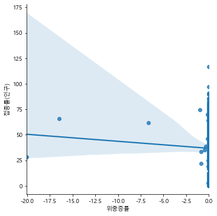

```python
sns.lmplot(x='위중증률', y='접종률(인구)', data=corona_part)
```

```python
corona_part[['위중증률', '접종률(인구)']].corr()
```

|  | 위중증률 | 접종률(인구) |
| --- | --- | --- |
| 위중증률 | 1.00000 | -0.04982 |
| 접종률(인구) | -0.04982 | 1.00000 |

### 결과 확인 : 인구당 접종률과 위중증률은 거의 관계가 없다.

### 오류가 없을까?

- 오류: -99999 데이터가 있었기에 정확하지 않을 수 있다.

```python
corona_part['위중증'].notnull().sum()
```

```
131
```

```python
corona_part = corona_part[ corona_part['위중증'].notnull() ]
corona_part['위중증'].isnull().sum()
```

```
0
```

```python
corona_part[['위중증률', '접종률(인구)']].corr()
```

|  | 위중증률 | 접종률(인구) |
| --- | --- | --- |
| 위중증률 | 1.000000 | 0.275532 |
| 접종률(인구) | 0.275532 | 1.000000 |

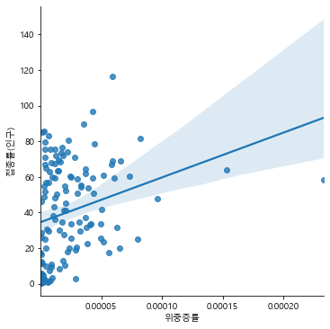

```python
sns.lmplot(x='위중증률', y='접종률(인구)', data=corona_part)
```

### 확인 : 데이터가 있는 131개국의 인구당 접종률과 위중증률은 0.2755로 양의 상관관계를 갖는다.

```python
corona
```

|  | 국가명 | eng_code | 발생률 | 인구수 | 확진자_합계 | 백신접종 | 접종률(인구) | 발생률_순위 | 접종률_순위 | 확진자비율_전체인구 | 1차접종 | 2차접종 | 위중증 | 치명(%) | 완치(%) | 확진자1일 | 사망자합계 | 사망자1일 | 완치합계 | 완치1일 | 접종비율(일간) | 사망률 | 위중증_수 | 위중증_증감 | 위중증_수2 | 위중증률 |
| --- | --- | --- | --- | --- | --- | --- | --- | --- | --- | --- | --- | --- | --- | --- | --- | --- | --- | --- | --- | --- | --- | --- | --- | --- | --- | --- |
| 0 | 미국 | U.S. | 129632 | 331002651 | 42908619 | 3.855860e+08 | 60.2 | 13.0 | 46.0 | 0.129632 | 63.8 | 54.60 | 24327\n-523 | 1.6 | 75.8 | 41814.0 | 691992 | 430.0 | 32508846.0 | 25620.0 | 763444.0 | 0.002091 | 24327 | -523 | 24327 | 7.349488e-05 |
| 1 | 인도 | India | 24277 | 1380004385 | 33483170 | 8.083893e+08 | 29.6 | 101.0 | 99.0 | 0.024263 | 43.7 | 14.50 | 8944 | 1.3 | 97.7 | 32085.0 | 445248 | 349.0 | 32715105.0 | 43938.0 | 9236028.0 | 0.000323 | 8944 | None | 8944 | 6.481139e-06 |
| 2 | 브라질 | Brazil | 99924 | 212559417 | 21239783 | 2.223227e+08 | 53.9 | 27.0 | 62.0 | 0.099924 | 69.4 | 37.80 | 8318 | 2.8 | 95.5 | 9458.0 | 590786 | 239.0 | 20280294.0 | NaN | 1721039.0 | 0.002779 | 8318 | None | 8318 | 3.913259e-05 |
| 3 | 영국 | U.K. | 109444 | 67886011 | 7429746 | 9.300209e+07 | 69.6 | 21.0 | 25.0 | 0.109444 | 72.7 | 66.50 | 1020 | 1.8 | 80.5 | 29007.0 | 135203 | 56.0 | 5981684.0 | 22993.0 | 83947.0 | 0.001992 | 1020 | None | 1020 | 1.502519e-05 |
| 4 | 러시아 | Russia | 49986 | 145934462 | 7294672 | 8.781062e+07 | 29.9 | 77.0 | 97.0 | 0.049986 | 31.9 | 27.60 | 2300 | 2.7 | 89.3 | 19744.0 | 198996 | 778.0 | 6510674.0 | 11992.0 | 354749.0 | 0.001364 | 2300 | None | 2300 | 1.576050e-05 |
| 5 | 프랑스 | France | 106557 | 65273511 | 6955333 | 9.226241e+07 | 71.2 | 23.0 | 22.0 | 0.106557 | 76.7 | 72.70 | 1832\n-168 | 1.7 | 95.6 | 5814.0 | 116030 | 28.0 | 6649678.0 | 23192.0 | 242012.0 | 0.001778 | 1832 | -168 | 1832 | 2.806652e-05 |
| 6 | 터키 | Turkey | 81187 | 84339067 | 6847259 | 1.051146e+08 | 63.2 | 45.0 | 41.0 | 0.081187 | 63.3 | 50.50 | 633 | 0.9 | 92.5 | 26398.0 | 61574 | 213.0 | 6337070.0 | 27160.0 | 472820.0 | 0.000730 | 633 | None | 633 | 7.505419e-06 |
| 7 | 이란 | Iran | 64794 | 83992949 | 5442232 | 4.200386e+07 | 25.2 | 62.0 | 107.0 | 0.064794 | 34.1 | 16.60 | 6707\n-58 | 2.2 | 88.1 | 17397.0 | 117526 | 344.0 | 4792117.0 | 27119.0 | 1114116.0 | 0.001399 | 6707 | -58 | 6707 | 7.985194e-05 |
| 8 | 아르헨티나 | Argentina | 115923 | 45195774 | 5239232 | 4.901757e+07 | 54.5 | 16.0 | 61.0 | 0.115923 | 64.5 | 44.30 | 1496\n-20 | 2.2 | 97.3 | 622.0 | 114428 | 61.0 | 5096283.0 | 2932.0 | 290888.0 | 0.002532 | 1496 | -20 | 1496 | 3.310044e-05 |
| 9 | 콜롬비아 | Colombia | 97107 | 50882891 | 4941064 | 3.833164e+07 | 38.0 | 30.0 | 80.0 | 0.097107 | 49.3 | 31.70 | 542 | 2.5 | 96.7 | 1813.0 | 125895 | 35.0 | 4779552.0 | 1756.0 | 163255.0 | 0.002474 | 542 | None | 542 | 1.065191e-05 |
| 10 | 스페인 | Spain | 105434 | 46754778 | 4929546 | 6.909466e+07 | 74.3 | 24.0 | 18.0 | 0.105434 | 80.4 | 77.00 | 1028 | 1.7 | 94.0 | NaN | 85783 | NaN | 4633527.0 | NaN | 140084.0 | 0.001835 | 1028 | None | 1028 | 2.198706e-05 |
| 11 | 이탈리아 | Italy | 76678 | 60461826 | 4636111 | 8.237767e+07 | 68.2 | 49.0 | 29.0 | 0.076678 | 73.3 | 67.90 | 530\n+11 | 2.8 | 94.7 | 3836.0 | 130310 | 26.0 | 4392265.0 | 3314.0 | 219232.0 | 0.002155 | 530 | +11 | 530 | 8.765862e-06 |
| 12 | 인도네시아 | Indonesia | 15328 | 273523615 | 4192695 | 1.234548e+08 | 23.1 | 109.0 | 111.0 | 0.015328 | 29.4 | 16.80 | NaN | 3.4 | 95.3 | 1932.0 | 140634 | 166.0 | 3996125.0 | 6799.0 | 1381673.0 | 0.000514 | NaN | NaN | -99999 | -3.655955e-04 |
| 13 | 독일 | Germany | 49569 | 83783942 | 4153067 | 1.054074e+08 | 63.4 | 79.0 | 40.0 | 0.049569 | 67.1 | 63.00 | 1217 | 2.3 | 93.9 | 6085.0 | 93592 | 34.0 | 3897800.0 | 15100.0 | 211307.0 | 0.001117 | 1217 | None | 1217 | 1.452546e-05 |
| 14 | 멕시코 | Mexico | 27686 | 128932753 | 3569677 | 9.527140e+07 | 37.3 | 95.0 | 81.0 | 0.027686 | 48.5 | 32.50 | 4798 | 7.6 | 81.9 | 4983.0 | 271503 | 200.0 | 2924904.0 | 8633.0 | 507287.0 | 0.002106 | 4798 | None | 4798 | 3.721320e-05 |
| 15 | 폴란드 | Poland | 76580 | 37846611 | 2898299 | 3.694714e+07 | 48.6 | 50.0 | 68.0 | 0.076580 | 51.7 | 50.70 | 113\n+2 | 2.6 | 91.8 | 364.0 | 75488 | NaN | 2659912.0 | 429.0 | 30007.0 | 0.001995 | 113 | +2 | 113 | 2.985736e-06 |
| 16 | 필리핀 | Philippines | 21770 | 109581078 | 2385616 | 4.051884e+07 | 18.9 | 105.0 | 121.0 | 0.021770 | 22.2 | 16.80 | 3170 | 1.5 | 91.0 | 18867.0 | 36934 | 146.0 | 2171832.0 | 20067.0 | 403560.0 | 0.000337 | 3170 | None | 3170 | 2.892835e-05 |
| 17 | 우크라이나 | Ukraine | 53749 | 43733762 | 2350646 | 1.655874e+07 | 19.8 | 75.0 | 119.0 | 0.053749 | 27.4 | 12.30 | 177 | 2.3 | 94.9 | 2265.0 | 54919 | 44.0 | 2231417.0 | 565.0 | 149085.0 | 0.001256 | 177 | None | 177 | 4.047216e-06 |
| 18 | 페루 | Peru | 65723 | 32971854 | 2167008 | 2.315884e+07 | 34.9 | 60.0 | 84.0 | 0.065723 | 42.0 | 27.90 | 1043\n+9 | 9.2 | NaN | 589.0 | 199006 | 30.0 | NaN | NaN | 225799.0 | 0.006036 | 1043 | +9 | 1043 | 3.163304e-05 |
| 19 | 말레이시아 | Malaysia | 64816 | 32365999 | 2097830 | 4.037506e+07 | 62.0 | 61.0 | 42.0 | 0.064816 | 67.3 | 56.20 | 1191\n+26 | 1.1 | 88.8 | 14954.0 | 23443 | 376.0 | 1863919.0 | 23469.0 | 269572.0 | 0.000724 | 1191 | +26 | 1191 | 3.679788e-05 |
| 20 | 네덜란드 | Netherlands | 115918 | 17134872 | 1986241 | 2.332039e+07 | 67.7 | 17.0 | 30.0 | 0.115918 | 70.0 | 63.40 | 208\n+11 | 0.9 | NaN | 1326.0 | 18123 | 9.0 | NaN | NaN | 40806.0 | 0.001058 | 208 | +11 | 208 | 1.213899e-05 |
| 21 | 이라크 | Iraq | 49187 | 40222493 | 1978412 | 6.672182e+06 | 8.5 | 80.0 | 138.0 | 0.049187 | 10.7 | 6.30 | 618\n+2 | 1.1 | 94.4 | 3192.0 | 21869 | 47.0 | 1867818.0 | 4878.0 | 306900.0 | 0.000544 | 618 | +2 | 618 | 1.536454e-05 |
| 22 | 체코 | Czech Republic | 157472 | 10708981 | 1686364 | 1.171255e+07 | 55.0 | 7.0 | 59.0 | 0.157472 | 56.7 | 55.30 | 28\n-1 | 1.8 | 97.9 | 182.0 | 30431 | 1.0 | 1650853.0 | 317.0 | 11672.0 | 0.002842 | 28 | -1 | 28 | 2.614628e-06 |
| 23 | 일본 | Japan | 13283 | 126476461 | 1680028 | 1.498825e+08 | 59.4 | 112.0 | 50.0 | 0.013283 | 65.5 | 53.30 | 1458\n-42 | 1.0 | 94.5 | 2218.0 | 17250 | 23.0 | 1586847.0 | 10277.0 | 1108541.0 | 0.000136 | 1458 | -42 | 1458 | 1.152784e-05 |
| 24 | 칠레 | Chile | 86196 | 19116201 | 1647746 | 3.078569e+07 | 80.6 | 38.0 | 9.0 | 0.086196 | 76.8 | 73.30 | 434\n-4 | 2.3 | 97.4 | 277.0 | 37367 | 8.0 | 1604353.0 | 419.0 | 83791.0 | 0.001955 | 434 | -4 | 434 | 2.270326e-05 |
| 25 | 캐나다 | Canada | 41687 | 37742154 | 1573359 | 5.506036e+07 | 73.4 | 86.0 | 19.0 | 0.041687 | 75.4 | 69.60 | 638 | 1.7 | 95.3 | 2032.0 | 27395 | 11.0 | 1499483.0 | 997.0 | 94377.0 | 0.000726 | 638 | None | 638 | 1.690418e-05 |
| 26 | 방글라데시 | Bangladesh | 9377 | 164689383 | 1544238 | 3.683279e+07 | 11.1 | 119.0 | 133.0 | 0.009377 | 13.3 | 8.80 | 1403 | 1.8 | 97.3 | 1555.0 | 27251 | 26.0 | 1503106.0 | 1565.0 | 363460.0 | 0.000165 | 1403 | None | 1403 | 8.519068e-06 |
| 27 | 태국 | Thailand | 21335 | 69799978 | 1489186 | 4.448566e+07 | 31.9 | 106.0 | 92.5 | 0.021335 | 40.8 | 20.50 | 4387 | 1.0 | 90.1 | 12709.0 | 15469 | 106.0 | 1341144.0 | 11125.0 | 632170.0 | 0.000222 | 4387 | None | 4387 | 6.285102e-05 |
| 28 | 이스라엘 | Israel | 142297 | 8655535 | 1231660 | 1.473209e+07 | 81.4 | 11.0 | 8.0 | 0.142297 | 67.0 | 61.60 | 714\n-12 | 0.6 | 93.2 | 9947.0 | 7541 | 30.0 | 1147578.0 | 17185.0 | 44039.0 | 0.000871 | 714 | -12 | 714 | 8.249057e-05 |
| 29 | 파키스탄 | Pakistan | 5550 | 220892340 | 1226008 | 7.298651e+07 | 17.8 | 130.0 | 123.0 | 0.005550 | 26.6 | 11.70 | 4840\n-124 | 2.2 | 92.6 | 2167.0 | 27246 | 40.0 | 1135038.0 | 2312.0 | 862739.0 | 0.000123 | 4840 | -124 | 4840 | 2.191113e-05 |

[output cut: 148 more lines]

### 실습과제 : 인구 100만 이상의 국가에 대해서 다시 수행해 보자.

- 접종률과 인구당 발생률 관계 확인
- 접종률과 사망률과 중증률 관계 확인

### 의문 : 그렇다면 전체 국가가 아닌 30개의 국가의 데이터를 확인해 보면 어떨까?

## 02. 접종률이 높은 30개의 국가의 데이터를 확인해 보기

```python
corona_top30 = corona[corona['접종률_순위']<=30]
corona_top30.shape
```

```
(30, 26)
```

```python
corona_top30
```

|  | 국가명 | eng_code | 발생률 | 인구수 | 확진자_합계 | 백신접종 | 접종률(인구) | 발생률_순위 | 접종률_순위 | 확진자비율_전체인구 | 1차접종 | 2차접종 | 위중증 | 치명(%) | 완치(%) | 확진자1일 | 사망자합계 | 사망자1일 | 완치합계 | 완치1일 | 접종비율(일간) | 사망률 | 위중증_수 | 위중증_증감 | 위중증_수2 | 위중증률 |
| --- | --- | --- | --- | --- | --- | --- | --- | --- | --- | --- | --- | --- | --- | --- | --- | --- | --- | --- | --- | --- | --- | --- | --- | --- | --- | --- |
| 3 | 영국 | U.K. | 109444 | 67886011 | 7429746 | 9.300209e+07 | 69.6 | 21.0 | 25.0 | 0.109444 | 72.7 | 66.5 | 1020 | 1.8 | 80.5 | 29007.0 | 135203 | 56.0 | 5981684.0 | 22993.0 | 83947.0 | 0.001992 | 1020 | None | 1020 | 0.000015 |
| 5 | 프랑스 | France | 106557 | 65273511 | 6955333 | 9.226241e+07 | 71.2 | 23.0 | 22.0 | 0.106557 | 76.7 | 72.7 | 1832\n-168 | 1.7 | 95.6 | 5814.0 | 116030 | 28.0 | 6649678.0 | 23192.0 | 242012.0 | 0.001778 | 1832 | -168 | 1832 | 0.000028 |
| 10 | 스페인 | Spain | 105434 | 46754778 | 4929546 | 6.909466e+07 | 74.3 | 24.0 | 18.0 | 0.105434 | 80.4 | 77.0 | 1028 | 1.7 | 94.0 | NaN | 85783 | NaN | 4633527.0 | NaN | 140084.0 | 0.001835 | 1028 | None | 1028 | 0.000022 |
| 11 | 이탈리아 | Italy | 76678 | 60461826 | 4636111 | 8.237767e+07 | 68.2 | 49.0 | 29.0 | 0.076678 | 73.3 | 67.9 | 530\n+11 | 2.8 | 94.7 | 3836.0 | 130310 | 26.0 | 4392265.0 | 3314.0 | 219232.0 | 0.002155 | 530 | +11 | 530 | 0.000009 |
| 20 | 네덜란드 | Netherlands | 115918 | 17134872 | 1986241 | 2.332039e+07 | 67.7 | 17.0 | 30.0 | 0.115918 | 70.0 | 63.4 | 208\n+11 | 0.9 | NaN | 1326.0 | 18123 | 9.0 | NaN | NaN | 40806.0 | 0.001058 | 208 | +11 | 208 | 0.000012 |
| 24 | 칠레 | Chile | 86196 | 19116201 | 1647746 | 3.078569e+07 | 80.6 | 38.0 | 9.0 | 0.086196 | 76.8 | 73.3 | 434\n-4 | 2.3 | 97.4 | 277.0 | 37367 | 8.0 | 1604353.0 | 419.0 | 83791.0 | 0.001955 | 434 | -4 | 434 | 0.000023 |
| 25 | 캐나다 | Canada | 41687 | 37742154 | 1573359 | 5.506036e+07 | 73.4 | 86.0 | 19.0 | 0.041687 | 75.4 | 69.6 | 638 | 1.7 | 95.3 | 2032.0 | 27395 | 11.0 | 1499483.0 | 997.0 | 94377.0 | 0.000726 | 638 | None | 638 | 0.000017 |
| 28 | 이스라엘 | Israel | 142297 | 8655535 | 1231660 | 1.473209e+07 | 81.4 | 11.0 | 8.0 | 0.142297 | 67.0 | 61.6 | 714\n-12 | 0.6 | 93.2 | 9947.0 | 7541 | 30.0 | 1147578.0 | 17185.0 | 44039.0 | 0.000871 | 714 | -12 | 714 | 0.000082 |
| 30 | 벨기에 | Belgium | 105251 | 11589623 | 1219814 | 1.644224e+07 | 71.8 | 25.0 | 21.0 | 0.105251 | 74.3 | 72.4 | 218 | 2.1 | 93.0 | NaN | 25497 | NaN | 1133872.0 | NaN | 12861.0 | 0.002200 | 218 | None | 218 | 0.000019 |
| 33 | 포르투갈 | Portugal | 104156 | 10196709 | 1062048 | 1.555099e+07 | 75.7 | 26.0 | 15.0 | 0.104156 | 86.1 | 81.0 | 86\n-4 | 1.7 | 95.1 | 677.0 | 17907 | 5.0 | 1010168.0 | 651.0 | 35729.0 | 0.001756 | 86 | -4 | 86 | 0.000008 |
| 40 | 쿠바 | Cuba | 71505 | 11326616 | 809911 | 1.776627e+07 | 78.4 | 56.0 | 11.0 | 0.071505 | 69.7 | 39.3 | 503\n+42 | 0.8 | 94.2 | 8544.0 | 6856 | 60.0 | 762679.0 | 7781.0 | 224330.0 | 0.000605 | 503 | +42 | 503 | 0.000044 |
| 42 | 아랍에미레이트 | UAE | 74113 | 9890402 | 733003 | 1.944587e+07 | 90.5 | 52.0 | 3.0 | 0.074113 | 84.5 | 74.5 | NaN | 0.3 | 98.9 | 313.0 | 2077 | 2.0 | 724855.0 | 409.0 | 71904.0 | 0.000210 | NaN | NaN | -99999 | -0.010111 |
| 64 | 우루과이 | Uruguay | 111588 | 3473730 | 387627 | 6.017599e+06 | 85.5 | 20.0 | 5.0 | 0.111588 | 77.2 | 72.7 | 11 | 1.6 | 98.0 | 72.0 | 6048 | NaN | 379986.0 | 103.0 | 14148.0 | 0.001741 | 11 | None | 11 | 0.000003 |
| 65 | 아일랜드 | Ireland | 76019 | 4937786 | 375367 | 7.119653e+06 | 71.9 | 51.0 | 20.0 | 0.076019 | 75.8 | 72.8 | 63\n-3 | 1.4 | 86.7 | 1224.0 | 5179 | NaN | 325349.0 | 2024.0 | 14259.0 | 0.001049 | 63 | -3 | 63 | 0.000013 |
| 68 | 덴마크 | Denmark | 61274 | 5792202 | 354913 | 8.773849e+06 | 75.6 | 65.0 | 16.0 | 0.061274 | 76.5 | 74.6 | 22\n-1 | 0.7 | 97.7 | 268.0 | 2630 | 2.0 | 346831.0 | 467.0 | 6462.0 | 0.000454 | 22 | -1 | 22 | 0.000004 |
| 78 | 바레인 | Bahrain | 161182 | 1701575 | 274264 | 2.535900e+06 | 85.4 | 5.0 | 6.0 | 0.161182 | 78.2 | 74.4 | 2 | 0.5 | 99.2 | 85.0 | 1388 | NaN | 272108.0 | 96.0 | 2395.0 | 0.000816 | 2 | None | 2 | 0.000001 |
| 81 | 카타르 | Qatar | 81785 | 2881053 | 235626 | 4.658268e+06 | 83.3 | 44.0 | 7.0 | 0.081785 | 84.4 | 79.4 | 19\n+1 | 0.3 | 99.1 | 240.0 | 604 | NaN | 233454.0 | 338.0 | 10124.0 | 0.000210 | 19 | +1 | 19 | 0.000007 |
| 86 | 노르웨이 | Norway | 33664 | 5421241 | 182501 | 7.586733e+06 | 70.8 | 91.0 | 23.0 | 0.033664 | 75.5 | 66.1 | 20\n+1 | 0.5 | 48.7 | 481.0 | 841 | NaN | 88952.0 | NaN | 36254.0 | 0.000155 | 20 | +1 | 20 | 0.000004 |
| 105 | 중국 | Mainland China | 67 | 1439323776 | 95738 | 2.174043e+09 | 77.6 | 176.0 | 12.0 | 0.000067 | 78.5 | 72.3 | NaN | 4.8 | 94.2 | 49.0 | 4636 | NaN | 90160.0 | 34.0 | 4494714.0 | 0.000003 | NaN | NaN | -99999 | -0.000069 |
| 109 | 몰디브 | Maldives | 154615 | 540544 | 83576 | 7.206660e+05 | 96.9 | 8.0 | 2.0 | 0.154615 | 105.0 | 88.7 | 23 | 0.3 | 97.7 | 82.0 | 229 | NaN | 81671.0 | 127.0 | 3817.0 | 0.000424 | 23 | None | 23 | 0.000043 |
| 111 | 싱가포르 | Singapore | 13299 | 5850342 | 77804 | 9.104751e+06 | 79.8 | 111.0 | 10.0 | 0.013299 | 81.7 | 79.7 | 21\n+3 | 0.1 | 90.7 | 1012.0 | 60 | NaN | 70600.0 | 476.0 | 10278.0 | 0.000010 | 21 | +3 | 21 | 0.000004 |
| 130 | 세이셸 | Seychelles | 212950 | 98347 | 20943 | 1.434900e+05 | 74.7 | 1.0 | 17.0 | 0.212950 | 77.4 | 72.6 | NaN | 0.5 | 96.7 | NaN | 114 | NaN | 20245.0 | NaN | 158.0 | 0.001159 | NaN | NaN | -99999 | -1.016798 |
| 139 | 아루바 | Aruba | 142826 | 106766 | 15249 | 1.544470e+05 | 68.9 | 10.0 | 27.0 | 0.142826 | 72.0 | 65.9 | 7 | 1.0 | 97.2 | 28.0 | 158 | NaN | 14822.0 | 32.0 | 597.0 | 0.001480 | 7 | None | 7 | 0.000066 |
| 150 | 아이슬란드 | Iceland | 33419 | 341243 | 11404 | 5.477880e+05 | 76.7 | 92.0 | 13.0 | 0.033419 | 78.8 | 76.8 | 6 | 0.3 | 96.6 | NaN | 33 | NaN | 11017.0 | NaN | 2048.0 | 0.000097 | 6 | None | 6 | 0.000018 |
| 154 | 맨섬 | Isle of Man | 84273 | 85033 | 7166 | 1.289150e+05 | 75.8 | 42.0 | 14.0 | 0.084273 | 77.0 | 74.7 | 1 | 0.5 | 94.8 | 25.0 | 38 | NaN | 6790.0 | NaN | 32.0 | 0.000447 | 1 | None | 1 | 0.000012 |
| 160 | 지브롤터 | Gibraltar | 162625 | 33691 | 5479 | 7.926900e+04 | 116.6 | 4.0 | 1.0 | 0.162625 | 117.2 | 116.0 | 2 | 1.8 | 96.9 | 2.0 | 97 | NaN | 5309.0 | 6.0 | 44.0 | 0.002879 | 2 | None | 2 | 0.000059 |
| 161 | 산마리노 | San Marino | 159706 | 33931 | 5419 | 4.691700e+04 | 69.0 | 6.0 | 26.0 | 0.159706 | 71.6 | 71.6 | 2\n+1 | 1.7 | 97.2 | 31.0 | 90 | NaN | 5269.0 | 29.0 | 86.0 | 0.002652 | 2 | +1 | 2 | 0.000059 |
| 164 | 버뮤다 | Bermuda | 71887 | 62278 | 4477 | 8.619400e+04 | 68.4 | 55.0 | 28.0 | 0.071887 | 69.1 | 67.7 | 1 | 0.9 | 67.2 | 259.0 | 42 | 4.0 | 3008.0 | 66.0 | 47.0 | 0.000674 | 1 | None | 1 | 0.000016 |
| 170 | 부탄 | Bhutan | 3366 | 771608 | 2597 | 1.046117e+06 | 70.2 | 141.0 | 24.0 | 0.003366 | 76.1 | 64.3 | NaN | 0.1 | 99.8 | NaN | 3 | NaN | 2593.0 | NaN | 256.0 | 0.000004 | NaN | NaN | -99999 | -0.129598 |
| 171 | 그린란드 | Greenland | 8173 | 56770 | 464 | 1.023570e+05 | 89.8 | 122.0 | 4.0 | 0.008173 | 124.5 | 62.9 | 2 | - | 78.0 | NaN | 0 | NaN | 362.0 | NaN | 300.0 | 0.000000 | 2 | None | 2 | 0.000035 |

### Learn 05. 데이터의 인덱스를 다시 재설정하기

- [].reset_index(inplace=True)

```python
corona_top30.reset_index(inplace=True)
corona_top30
```

|  | level_0 | index | 국가명 | eng_code | 발생률 | 인구수 | 확진자_합계 | 백신접종 | 접종률(인구) | 발생률_순위 | 접종률_순위 | 확진자비율_전체인구 | 1차접종 | 2차접종 | 위중증 | 치명(%) | 완치(%) | 확진자1일 | 사망자합계 | 사망자1일 | 완치합계 | 완치1일 | 접종비율(일간) | 사망률 | 위중증_수 | 위중증_증감 | 위중증_수2 | 위중증률 |
| --- | --- | --- | --- | --- | --- | --- | --- | --- | --- | --- | --- | --- | --- | --- | --- | --- | --- | --- | --- | --- | --- | --- | --- | --- | --- | --- | --- | --- |
| 0 | 0 | 3 | 영국 | U.K. | 109444 | 67886011 | 7429746 | 9.300209e+07 | 69.6 | 21.0 | 25.0 | 0.109444 | 72.7 | 66.5 | 1020 | 1.8 | 80.5 | 29007.0 | 135203 | 56.0 | 5981684.0 | 22993.0 | 83947.0 | 0.001992 | 1020 | None | 1020 | 0.000015 |
| 1 | 1 | 5 | 프랑스 | France | 106557 | 65273511 | 6955333 | 9.226241e+07 | 71.2 | 23.0 | 22.0 | 0.106557 | 76.7 | 72.7 | 1832\n-168 | 1.7 | 95.6 | 5814.0 | 116030 | 28.0 | 6649678.0 | 23192.0 | 242012.0 | 0.001778 | 1832 | -168 | 1832 | 0.000028 |
| 2 | 2 | 10 | 스페인 | Spain | 105434 | 46754778 | 4929546 | 6.909466e+07 | 74.3 | 24.0 | 18.0 | 0.105434 | 80.4 | 77.0 | 1028 | 1.7 | 94.0 | NaN | 85783 | NaN | 4633527.0 | NaN | 140084.0 | 0.001835 | 1028 | None | 1028 | 0.000022 |
| 3 | 3 | 11 | 이탈리아 | Italy | 76678 | 60461826 | 4636111 | 8.237767e+07 | 68.2 | 49.0 | 29.0 | 0.076678 | 73.3 | 67.9 | 530\n+11 | 2.8 | 94.7 | 3836.0 | 130310 | 26.0 | 4392265.0 | 3314.0 | 219232.0 | 0.002155 | 530 | +11 | 530 | 0.000009 |
| 4 | 4 | 20 | 네덜란드 | Netherlands | 115918 | 17134872 | 1986241 | 2.332039e+07 | 67.7 | 17.0 | 30.0 | 0.115918 | 70.0 | 63.4 | 208\n+11 | 0.9 | NaN | 1326.0 | 18123 | 9.0 | NaN | NaN | 40806.0 | 0.001058 | 208 | +11 | 208 | 0.000012 |
| 5 | 5 | 24 | 칠레 | Chile | 86196 | 19116201 | 1647746 | 3.078569e+07 | 80.6 | 38.0 | 9.0 | 0.086196 | 76.8 | 73.3 | 434\n-4 | 2.3 | 97.4 | 277.0 | 37367 | 8.0 | 1604353.0 | 419.0 | 83791.0 | 0.001955 | 434 | -4 | 434 | 0.000023 |
| 6 | 6 | 25 | 캐나다 | Canada | 41687 | 37742154 | 1573359 | 5.506036e+07 | 73.4 | 86.0 | 19.0 | 0.041687 | 75.4 | 69.6 | 638 | 1.7 | 95.3 | 2032.0 | 27395 | 11.0 | 1499483.0 | 997.0 | 94377.0 | 0.000726 | 638 | None | 638 | 0.000017 |
| 7 | 7 | 28 | 이스라엘 | Israel | 142297 | 8655535 | 1231660 | 1.473209e+07 | 81.4 | 11.0 | 8.0 | 0.142297 | 67.0 | 61.6 | 714\n-12 | 0.6 | 93.2 | 9947.0 | 7541 | 30.0 | 1147578.0 | 17185.0 | 44039.0 | 0.000871 | 714 | -12 | 714 | 0.000082 |
| 8 | 8 | 30 | 벨기에 | Belgium | 105251 | 11589623 | 1219814 | 1.644224e+07 | 71.8 | 25.0 | 21.0 | 0.105251 | 74.3 | 72.4 | 218 | 2.1 | 93.0 | NaN | 25497 | NaN | 1133872.0 | NaN | 12861.0 | 0.002200 | 218 | None | 218 | 0.000019 |
| 9 | 9 | 33 | 포르투갈 | Portugal | 104156 | 10196709 | 1062048 | 1.555099e+07 | 75.7 | 26.0 | 15.0 | 0.104156 | 86.1 | 81.0 | 86\n-4 | 1.7 | 95.1 | 677.0 | 17907 | 5.0 | 1010168.0 | 651.0 | 35729.0 | 0.001756 | 86 | -4 | 86 | 0.000008 |
| 10 | 10 | 40 | 쿠바 | Cuba | 71505 | 11326616 | 809911 | 1.776627e+07 | 78.4 | 56.0 | 11.0 | 0.071505 | 69.7 | 39.3 | 503\n+42 | 0.8 | 94.2 | 8544.0 | 6856 | 60.0 | 762679.0 | 7781.0 | 224330.0 | 0.000605 | 503 | +42 | 503 | 0.000044 |
| 11 | 11 | 42 | 아랍에미레이트 | UAE | 74113 | 9890402 | 733003 | 1.944587e+07 | 90.5 | 52.0 | 3.0 | 0.074113 | 84.5 | 74.5 | NaN | 0.3 | 98.9 | 313.0 | 2077 | 2.0 | 724855.0 | 409.0 | 71904.0 | 0.000210 | NaN | NaN | -99999 | -0.010111 |
| 12 | 12 | 64 | 우루과이 | Uruguay | 111588 | 3473730 | 387627 | 6.017599e+06 | 85.5 | 20.0 | 5.0 | 0.111588 | 77.2 | 72.7 | 11 | 1.6 | 98.0 | 72.0 | 6048 | NaN | 379986.0 | 103.0 | 14148.0 | 0.001741 | 11 | None | 11 | 0.000003 |
| 13 | 13 | 65 | 아일랜드 | Ireland | 76019 | 4937786 | 375367 | 7.119653e+06 | 71.9 | 51.0 | 20.0 | 0.076019 | 75.8 | 72.8 | 63\n-3 | 1.4 | 86.7 | 1224.0 | 5179 | NaN | 325349.0 | 2024.0 | 14259.0 | 0.001049 | 63 | -3 | 63 | 0.000013 |
| 14 | 14 | 68 | 덴마크 | Denmark | 61274 | 5792202 | 354913 | 8.773849e+06 | 75.6 | 65.0 | 16.0 | 0.061274 | 76.5 | 74.6 | 22\n-1 | 0.7 | 97.7 | 268.0 | 2630 | 2.0 | 346831.0 | 467.0 | 6462.0 | 0.000454 | 22 | -1 | 22 | 0.000004 |
| 15 | 15 | 78 | 바레인 | Bahrain | 161182 | 1701575 | 274264 | 2.535900e+06 | 85.4 | 5.0 | 6.0 | 0.161182 | 78.2 | 74.4 | 2 | 0.5 | 99.2 | 85.0 | 1388 | NaN | 272108.0 | 96.0 | 2395.0 | 0.000816 | 2 | None | 2 | 0.000001 |
| 16 | 16 | 81 | 카타르 | Qatar | 81785 | 2881053 | 235626 | 4.658268e+06 | 83.3 | 44.0 | 7.0 | 0.081785 | 84.4 | 79.4 | 19\n+1 | 0.3 | 99.1 | 240.0 | 604 | NaN | 233454.0 | 338.0 | 10124.0 | 0.000210 | 19 | +1 | 19 | 0.000007 |
| 17 | 17 | 86 | 노르웨이 | Norway | 33664 | 5421241 | 182501 | 7.586733e+06 | 70.8 | 91.0 | 23.0 | 0.033664 | 75.5 | 66.1 | 20\n+1 | 0.5 | 48.7 | 481.0 | 841 | NaN | 88952.0 | NaN | 36254.0 | 0.000155 | 20 | +1 | 20 | 0.000004 |
| 18 | 18 | 105 | 중국 | Mainland China | 67 | 1439323776 | 95738 | 2.174043e+09 | 77.6 | 176.0 | 12.0 | 0.000067 | 78.5 | 72.3 | NaN | 4.8 | 94.2 | 49.0 | 4636 | NaN | 90160.0 | 34.0 | 4494714.0 | 0.000003 | NaN | NaN | -99999 | -0.000069 |
| 19 | 19 | 109 | 몰디브 | Maldives | 154615 | 540544 | 83576 | 7.206660e+05 | 96.9 | 8.0 | 2.0 | 0.154615 | 105.0 | 88.7 | 23 | 0.3 | 97.7 | 82.0 | 229 | NaN | 81671.0 | 127.0 | 3817.0 | 0.000424 | 23 | None | 23 | 0.000043 |
| 20 | 20 | 111 | 싱가포르 | Singapore | 13299 | 5850342 | 77804 | 9.104751e+06 | 79.8 | 111.0 | 10.0 | 0.013299 | 81.7 | 79.7 | 21\n+3 | 0.1 | 90.7 | 1012.0 | 60 | NaN | 70600.0 | 476.0 | 10278.0 | 0.000010 | 21 | +3 | 21 | 0.000004 |
| 21 | 21 | 130 | 세이셸 | Seychelles | 212950 | 98347 | 20943 | 1.434900e+05 | 74.7 | 1.0 | 17.0 | 0.212950 | 77.4 | 72.6 | NaN | 0.5 | 96.7 | NaN | 114 | NaN | 20245.0 | NaN | 158.0 | 0.001159 | NaN | NaN | -99999 | -1.016798 |
| 22 | 22 | 139 | 아루바 | Aruba | 142826 | 106766 | 15249 | 1.544470e+05 | 68.9 | 10.0 | 27.0 | 0.142826 | 72.0 | 65.9 | 7 | 1.0 | 97.2 | 28.0 | 158 | NaN | 14822.0 | 32.0 | 597.0 | 0.001480 | 7 | None | 7 | 0.000066 |
| 23 | 23 | 150 | 아이슬란드 | Iceland | 33419 | 341243 | 11404 | 5.477880e+05 | 76.7 | 92.0 | 13.0 | 0.033419 | 78.8 | 76.8 | 6 | 0.3 | 96.6 | NaN | 33 | NaN | 11017.0 | NaN | 2048.0 | 0.000097 | 6 | None | 6 | 0.000018 |
| 24 | 24 | 154 | 맨섬 | Isle of Man | 84273 | 85033 | 7166 | 1.289150e+05 | 75.8 | 42.0 | 14.0 | 0.084273 | 77.0 | 74.7 | 1 | 0.5 | 94.8 | 25.0 | 38 | NaN | 6790.0 | NaN | 32.0 | 0.000447 | 1 | None | 1 | 0.000012 |
| 25 | 25 | 160 | 지브롤터 | Gibraltar | 162625 | 33691 | 5479 | 7.926900e+04 | 116.6 | 4.0 | 1.0 | 0.162625 | 117.2 | 116.0 | 2 | 1.8 | 96.9 | 2.0 | 97 | NaN | 5309.0 | 6.0 | 44.0 | 0.002879 | 2 | None | 2 | 0.000059 |
| 26 | 26 | 161 | 산마리노 | San Marino | 159706 | 33931 | 5419 | 4.691700e+04 | 69.0 | 6.0 | 26.0 | 0.159706 | 71.6 | 71.6 | 2\n+1 | 1.7 | 97.2 | 31.0 | 90 | NaN | 5269.0 | 29.0 | 86.0 | 0.002652 | 2 | +1 | 2 | 0.000059 |
| 27 | 27 | 164 | 버뮤다 | Bermuda | 71887 | 62278 | 4477 | 8.619400e+04 | 68.4 | 55.0 | 28.0 | 0.071887 | 69.1 | 67.7 | 1 | 0.9 | 67.2 | 259.0 | 42 | 4.0 | 3008.0 | 66.0 | 47.0 | 0.000674 | 1 | None | 1 | 0.000016 |
| 28 | 28 | 170 | 부탄 | Bhutan | 3366 | 771608 | 2597 | 1.046117e+06 | 70.2 | 141.0 | 24.0 | 0.003366 | 76.1 | 64.3 | NaN | 0.1 | 99.8 | NaN | 3 | NaN | 2593.0 | NaN | 256.0 | 0.000004 | NaN | NaN | -99999 | -0.129598 |
| 29 | 29 | 171 | 그린란드 | Greenland | 8173 | 56770 | 464 | 1.023570e+05 | 89.8 | 122.0 | 4.0 | 0.008173 | 124.5 | 62.9 | 2 | - | 78.0 | NaN | 0 | NaN | 362.0 | NaN | 300.0 | 0.000000 | 2 | None | 2 | 0.000035 |

### Learn 06. 데이터를 정렬시키기 2가지

- sort_index() : 인덱스를 기준으로 정렬
- sort_values(by=[], ascending=False, axis=0,1, inplace=True or False) : 컬럼의 값을 기준으로 데이터 정렬
  - by : 정렬할 열 선택
  - axis : 0 : index, 1: columns

```python
corona_top30.columns
```

```
Index(['level_0', 'index', '국가명', 'eng_code', '발생률', '인구수', '확진자_합계', '백신접종',
       '접종률(인구)', '발생률_순위', '접종률_순위', '확진자비율_전체인구', '1차접종', '2차접종', '위중증',
       '치명(%)', '완치(%)', '확진자1일', '사망자합계', '사망자1일', '완치합계', '완치1일', '접종비율(일간)',
       '사망률', '위중증_수', '위중증_증감', '위중증_수2', '위중증률'],
      dtype='object')
```

```python
corona_sel = ['국가명', '발생률', '인구수', '확진자_합계', '백신접종', '접종률(인구)', '확진자비율_전체인구',
              '발생률_순위', '접종률_순위', '사망률', '위중증_수2', '위중증_증감', '위중증률']
corona_top30_part = corona_top30[corona_sel]
corona_top30_part
```

|  | 국가명 | 발생률 | 인구수 | 확진자_합계 | 백신접종 | 접종률(인구) | 확진자비율_전체인구 | 발생률_순위 | 접종률_순위 | 사망률 | 위중증_수2 | 위중증_증감 | 위중증률 |
| --- | --- | --- | --- | --- | --- | --- | --- | --- | --- | --- | --- | --- | --- |
| 0 | 영국 | 109444 | 67886011 | 7429746 | 9.300209e+07 | 69.6 | 0.109444 | 21.0 | 25.0 | 0.001992 | 1020 | None | 0.000015 |
| 1 | 프랑스 | 106557 | 65273511 | 6955333 | 9.226241e+07 | 71.2 | 0.106557 | 23.0 | 22.0 | 0.001778 | 1832 | -168 | 0.000028 |
| 2 | 스페인 | 105434 | 46754778 | 4929546 | 6.909466e+07 | 74.3 | 0.105434 | 24.0 | 18.0 | 0.001835 | 1028 | None | 0.000022 |
| 3 | 이탈리아 | 76678 | 60461826 | 4636111 | 8.237767e+07 | 68.2 | 0.076678 | 49.0 | 29.0 | 0.002155 | 530 | +11 | 0.000009 |
| 4 | 네덜란드 | 115918 | 17134872 | 1986241 | 2.332039e+07 | 67.7 | 0.115918 | 17.0 | 30.0 | 0.001058 | 208 | +11 | 0.000012 |
| 5 | 칠레 | 86196 | 19116201 | 1647746 | 3.078569e+07 | 80.6 | 0.086196 | 38.0 | 9.0 | 0.001955 | 434 | -4 | 0.000023 |
| 6 | 캐나다 | 41687 | 37742154 | 1573359 | 5.506036e+07 | 73.4 | 0.041687 | 86.0 | 19.0 | 0.000726 | 638 | None | 0.000017 |
| 7 | 이스라엘 | 142297 | 8655535 | 1231660 | 1.473209e+07 | 81.4 | 0.142297 | 11.0 | 8.0 | 0.000871 | 714 | -12 | 0.000082 |
| 8 | 벨기에 | 105251 | 11589623 | 1219814 | 1.644224e+07 | 71.8 | 0.105251 | 25.0 | 21.0 | 0.002200 | 218 | None | 0.000019 |
| 9 | 포르투갈 | 104156 | 10196709 | 1062048 | 1.555099e+07 | 75.7 | 0.104156 | 26.0 | 15.0 | 0.001756 | 86 | -4 | 0.000008 |
| 10 | 쿠바 | 71505 | 11326616 | 809911 | 1.776627e+07 | 78.4 | 0.071505 | 56.0 | 11.0 | 0.000605 | 503 | +42 | 0.000044 |
| 11 | 아랍에미레이트 | 74113 | 9890402 | 733003 | 1.944587e+07 | 90.5 | 0.074113 | 52.0 | 3.0 | 0.000210 | -99999 | NaN | -0.010111 |
| 12 | 우루과이 | 111588 | 3473730 | 387627 | 6.017599e+06 | 85.5 | 0.111588 | 20.0 | 5.0 | 0.001741 | 11 | None | 0.000003 |
| 13 | 아일랜드 | 76019 | 4937786 | 375367 | 7.119653e+06 | 71.9 | 0.076019 | 51.0 | 20.0 | 0.001049 | 63 | -3 | 0.000013 |
| 14 | 덴마크 | 61274 | 5792202 | 354913 | 8.773849e+06 | 75.6 | 0.061274 | 65.0 | 16.0 | 0.000454 | 22 | -1 | 0.000004 |
| 15 | 바레인 | 161182 | 1701575 | 274264 | 2.535900e+06 | 85.4 | 0.161182 | 5.0 | 6.0 | 0.000816 | 2 | None | 0.000001 |
| 16 | 카타르 | 81785 | 2881053 | 235626 | 4.658268e+06 | 83.3 | 0.081785 | 44.0 | 7.0 | 0.000210 | 19 | +1 | 0.000007 |
| 17 | 노르웨이 | 33664 | 5421241 | 182501 | 7.586733e+06 | 70.8 | 0.033664 | 91.0 | 23.0 | 0.000155 | 20 | +1 | 0.000004 |
| 18 | 중국 | 67 | 1439323776 | 95738 | 2.174043e+09 | 77.6 | 0.000067 | 176.0 | 12.0 | 0.000003 | -99999 | NaN | -0.000069 |
| 19 | 몰디브 | 154615 | 540544 | 83576 | 7.206660e+05 | 96.9 | 0.154615 | 8.0 | 2.0 | 0.000424 | 23 | None | 0.000043 |
| 20 | 싱가포르 | 13299 | 5850342 | 77804 | 9.104751e+06 | 79.8 | 0.013299 | 111.0 | 10.0 | 0.000010 | 21 | +3 | 0.000004 |
| 21 | 세이셸 | 212950 | 98347 | 20943 | 1.434900e+05 | 74.7 | 0.212950 | 1.0 | 17.0 | 0.001159 | -99999 | NaN | -1.016798 |
| 22 | 아루바 | 142826 | 106766 | 15249 | 1.544470e+05 | 68.9 | 0.142826 | 10.0 | 27.0 | 0.001480 | 7 | None | 0.000066 |
| 23 | 아이슬란드 | 33419 | 341243 | 11404 | 5.477880e+05 | 76.7 | 0.033419 | 92.0 | 13.0 | 0.000097 | 6 | None | 0.000018 |
| 24 | 맨섬 | 84273 | 85033 | 7166 | 1.289150e+05 | 75.8 | 0.084273 | 42.0 | 14.0 | 0.000447 | 1 | None | 0.000012 |
| 25 | 지브롤터 | 162625 | 33691 | 5479 | 7.926900e+04 | 116.6 | 0.162625 | 4.0 | 1.0 | 0.002879 | 2 | None | 0.000059 |
| 26 | 산마리노 | 159706 | 33931 | 5419 | 4.691700e+04 | 69.0 | 0.159706 | 6.0 | 26.0 | 0.002652 | 2 | +1 | 0.000059 |
| 27 | 버뮤다 | 71887 | 62278 | 4477 | 8.619400e+04 | 68.4 | 0.071887 | 55.0 | 28.0 | 0.000674 | 1 | None | 0.000016 |
| 28 | 부탄 | 3366 | 771608 | 2597 | 1.046117e+06 | 70.2 | 0.003366 | 141.0 | 24.0 | 0.000004 | -99999 | NaN | -0.129598 |
| 29 | 그린란드 | 8173 | 56770 | 464 | 1.023570e+05 | 89.8 | 0.008173 | 122.0 | 4.0 | 0.000000 | 2 | None | 0.000035 |

```python
# 접종률_순위 을 기준으로 정렬, 내림차순
corona_top30_part_sorted = corona_top30_part.sort_values(by=['접종률_순위'], ascending=True)
```

```python
corona_top30_part_sorted
```

|  | 국가명 | 발생률 | 인구수 | 확진자_합계 | 백신접종 | 접종률(인구) | 확진자비율_전체인구 | 발생률_순위 | 접종률_순위 | 사망률 | 위중증_수2 | 위중증_증감 | 위중증률 |
| --- | --- | --- | --- | --- | --- | --- | --- | --- | --- | --- | --- | --- | --- |
| 25 | 지브롤터 | 162625 | 33691 | 5479 | 7.926900e+04 | 116.6 | 0.162625 | 4.0 | 1.0 | 0.002879 | 2 | None | 0.000059 |
| 19 | 몰디브 | 154615 | 540544 | 83576 | 7.206660e+05 | 96.9 | 0.154615 | 8.0 | 2.0 | 0.000424 | 23 | None | 0.000043 |
| 11 | 아랍에미레이트 | 74113 | 9890402 | 733003 | 1.944587e+07 | 90.5 | 0.074113 | 52.0 | 3.0 | 0.000210 | -99999 | NaN | -0.010111 |
| 29 | 그린란드 | 8173 | 56770 | 464 | 1.023570e+05 | 89.8 | 0.008173 | 122.0 | 4.0 | 0.000000 | 2 | None | 0.000035 |
| 12 | 우루과이 | 111588 | 3473730 | 387627 | 6.017599e+06 | 85.5 | 0.111588 | 20.0 | 5.0 | 0.001741 | 11 | None | 0.000003 |
| 15 | 바레인 | 161182 | 1701575 | 274264 | 2.535900e+06 | 85.4 | 0.161182 | 5.0 | 6.0 | 0.000816 | 2 | None | 0.000001 |
| 16 | 카타르 | 81785 | 2881053 | 235626 | 4.658268e+06 | 83.3 | 0.081785 | 44.0 | 7.0 | 0.000210 | 19 | +1 | 0.000007 |
| 7 | 이스라엘 | 142297 | 8655535 | 1231660 | 1.473209e+07 | 81.4 | 0.142297 | 11.0 | 8.0 | 0.000871 | 714 | -12 | 0.000082 |
| 5 | 칠레 | 86196 | 19116201 | 1647746 | 3.078569e+07 | 80.6 | 0.086196 | 38.0 | 9.0 | 0.001955 | 434 | -4 | 0.000023 |
| 20 | 싱가포르 | 13299 | 5850342 | 77804 | 9.104751e+06 | 79.8 | 0.013299 | 111.0 | 10.0 | 0.000010 | 21 | +3 | 0.000004 |
| 10 | 쿠바 | 71505 | 11326616 | 809911 | 1.776627e+07 | 78.4 | 0.071505 | 56.0 | 11.0 | 0.000605 | 503 | +42 | 0.000044 |
| 18 | 중국 | 67 | 1439323776 | 95738 | 2.174043e+09 | 77.6 | 0.000067 | 176.0 | 12.0 | 0.000003 | -99999 | NaN | -0.000069 |
| 23 | 아이슬란드 | 33419 | 341243 | 11404 | 5.477880e+05 | 76.7 | 0.033419 | 92.0 | 13.0 | 0.000097 | 6 | None | 0.000018 |
| 24 | 맨섬 | 84273 | 85033 | 7166 | 1.289150e+05 | 75.8 | 0.084273 | 42.0 | 14.0 | 0.000447 | 1 | None | 0.000012 |
| 9 | 포르투갈 | 104156 | 10196709 | 1062048 | 1.555099e+07 | 75.7 | 0.104156 | 26.0 | 15.0 | 0.001756 | 86 | -4 | 0.000008 |
| 14 | 덴마크 | 61274 | 5792202 | 354913 | 8.773849e+06 | 75.6 | 0.061274 | 65.0 | 16.0 | 0.000454 | 22 | -1 | 0.000004 |
| 21 | 세이셸 | 212950 | 98347 | 20943 | 1.434900e+05 | 74.7 | 0.212950 | 1.0 | 17.0 | 0.001159 | -99999 | NaN | -1.016798 |
| 2 | 스페인 | 105434 | 46754778 | 4929546 | 6.909466e+07 | 74.3 | 0.105434 | 24.0 | 18.0 | 0.001835 | 1028 | None | 0.000022 |
| 6 | 캐나다 | 41687 | 37742154 | 1573359 | 5.506036e+07 | 73.4 | 0.041687 | 86.0 | 19.0 | 0.000726 | 638 | None | 0.000017 |
| 13 | 아일랜드 | 76019 | 4937786 | 375367 | 7.119653e+06 | 71.9 | 0.076019 | 51.0 | 20.0 | 0.001049 | 63 | -3 | 0.000013 |
| 8 | 벨기에 | 105251 | 11589623 | 1219814 | 1.644224e+07 | 71.8 | 0.105251 | 25.0 | 21.0 | 0.002200 | 218 | None | 0.000019 |
| 1 | 프랑스 | 106557 | 65273511 | 6955333 | 9.226241e+07 | 71.2 | 0.106557 | 23.0 | 22.0 | 0.001778 | 1832 | -168 | 0.000028 |
| 17 | 노르웨이 | 33664 | 5421241 | 182501 | 7.586733e+06 | 70.8 | 0.033664 | 91.0 | 23.0 | 0.000155 | 20 | +1 | 0.000004 |
| 28 | 부탄 | 3366 | 771608 | 2597 | 1.046117e+06 | 70.2 | 0.003366 | 141.0 | 24.0 | 0.000004 | -99999 | NaN | -0.129598 |
| 0 | 영국 | 109444 | 67886011 | 7429746 | 9.300209e+07 | 69.6 | 0.109444 | 21.0 | 25.0 | 0.001992 | 1020 | None | 0.000015 |
| 26 | 산마리노 | 159706 | 33931 | 5419 | 4.691700e+04 | 69.0 | 0.159706 | 6.0 | 26.0 | 0.002652 | 2 | +1 | 0.000059 |
| 22 | 아루바 | 142826 | 106766 | 15249 | 1.544470e+05 | 68.9 | 0.142826 | 10.0 | 27.0 | 0.001480 | 7 | None | 0.000066 |
| 27 | 버뮤다 | 71887 | 62278 | 4477 | 8.619400e+04 | 68.4 | 0.071887 | 55.0 | 28.0 | 0.000674 | 1 | None | 0.000016 |
| 3 | 이탈리아 | 76678 | 60461826 | 4636111 | 8.237767e+07 | 68.2 | 0.076678 | 49.0 | 29.0 | 0.002155 | 530 | +11 | 0.000009 |
| 4 | 네덜란드 | 115918 | 17134872 | 1986241 | 2.332039e+07 | 67.7 | 0.115918 | 17.0 | 30.0 | 0.001058 | 208 | +11 | 0.000012 |

```python
corona_top30_part_sorted.reset_index(inplace=True)
```

```python
corona_top30_part_sorted
```

|  | index | 국가명 | 발생률 | 인구수 | 확진자_합계 | 백신접종 | 접종률(인구) | 확진자비율_전체인구 | 발생률_순위 | 접종률_순위 | 사망률 | 위중증_수2 | 위중증_증감 | 위중증률 |
| --- | --- | --- | --- | --- | --- | --- | --- | --- | --- | --- | --- | --- | --- | --- |
| 0 | 25 | 지브롤터 | 162625 | 33691 | 5479 | 7.926900e+04 | 116.6 | 0.162625 | 4.0 | 1.0 | 0.002879 | 2 | None | 0.000059 |
| 1 | 19 | 몰디브 | 154615 | 540544 | 83576 | 7.206660e+05 | 96.9 | 0.154615 | 8.0 | 2.0 | 0.000424 | 23 | None | 0.000043 |
| 2 | 11 | 아랍에미레이트 | 74113 | 9890402 | 733003 | 1.944587e+07 | 90.5 | 0.074113 | 52.0 | 3.0 | 0.000210 | -99999 | NaN | -0.010111 |
| 3 | 29 | 그린란드 | 8173 | 56770 | 464 | 1.023570e+05 | 89.8 | 0.008173 | 122.0 | 4.0 | 0.000000 | 2 | None | 0.000035 |
| 4 | 12 | 우루과이 | 111588 | 3473730 | 387627 | 6.017599e+06 | 85.5 | 0.111588 | 20.0 | 5.0 | 0.001741 | 11 | None | 0.000003 |
| 5 | 15 | 바레인 | 161182 | 1701575 | 274264 | 2.535900e+06 | 85.4 | 0.161182 | 5.0 | 6.0 | 0.000816 | 2 | None | 0.000001 |
| 6 | 16 | 카타르 | 81785 | 2881053 | 235626 | 4.658268e+06 | 83.3 | 0.081785 | 44.0 | 7.0 | 0.000210 | 19 | +1 | 0.000007 |
| 7 | 7 | 이스라엘 | 142297 | 8655535 | 1231660 | 1.473209e+07 | 81.4 | 0.142297 | 11.0 | 8.0 | 0.000871 | 714 | -12 | 0.000082 |
| 8 | 5 | 칠레 | 86196 | 19116201 | 1647746 | 3.078569e+07 | 80.6 | 0.086196 | 38.0 | 9.0 | 0.001955 | 434 | -4 | 0.000023 |
| 9 | 20 | 싱가포르 | 13299 | 5850342 | 77804 | 9.104751e+06 | 79.8 | 0.013299 | 111.0 | 10.0 | 0.000010 | 21 | +3 | 0.000004 |
| 10 | 10 | 쿠바 | 71505 | 11326616 | 809911 | 1.776627e+07 | 78.4 | 0.071505 | 56.0 | 11.0 | 0.000605 | 503 | +42 | 0.000044 |
| 11 | 18 | 중국 | 67 | 1439323776 | 95738 | 2.174043e+09 | 77.6 | 0.000067 | 176.0 | 12.0 | 0.000003 | -99999 | NaN | -0.000069 |
| 12 | 23 | 아이슬란드 | 33419 | 341243 | 11404 | 5.477880e+05 | 76.7 | 0.033419 | 92.0 | 13.0 | 0.000097 | 6 | None | 0.000018 |
| 13 | 24 | 맨섬 | 84273 | 85033 | 7166 | 1.289150e+05 | 75.8 | 0.084273 | 42.0 | 14.0 | 0.000447 | 1 | None | 0.000012 |
| 14 | 9 | 포르투갈 | 104156 | 10196709 | 1062048 | 1.555099e+07 | 75.7 | 0.104156 | 26.0 | 15.0 | 0.001756 | 86 | -4 | 0.000008 |
| 15 | 14 | 덴마크 | 61274 | 5792202 | 354913 | 8.773849e+06 | 75.6 | 0.061274 | 65.0 | 16.0 | 0.000454 | 22 | -1 | 0.000004 |
| 16 | 21 | 세이셸 | 212950 | 98347 | 20943 | 1.434900e+05 | 74.7 | 0.212950 | 1.0 | 17.0 | 0.001159 | -99999 | NaN | -1.016798 |
| 17 | 2 | 스페인 | 105434 | 46754778 | 4929546 | 6.909466e+07 | 74.3 | 0.105434 | 24.0 | 18.0 | 0.001835 | 1028 | None | 0.000022 |
| 18 | 6 | 캐나다 | 41687 | 37742154 | 1573359 | 5.506036e+07 | 73.4 | 0.041687 | 86.0 | 19.0 | 0.000726 | 638 | None | 0.000017 |
| 19 | 13 | 아일랜드 | 76019 | 4937786 | 375367 | 7.119653e+06 | 71.9 | 0.076019 | 51.0 | 20.0 | 0.001049 | 63 | -3 | 0.000013 |
| 20 | 8 | 벨기에 | 105251 | 11589623 | 1219814 | 1.644224e+07 | 71.8 | 0.105251 | 25.0 | 21.0 | 0.002200 | 218 | None | 0.000019 |
| 21 | 1 | 프랑스 | 106557 | 65273511 | 6955333 | 9.226241e+07 | 71.2 | 0.106557 | 23.0 | 22.0 | 0.001778 | 1832 | -168 | 0.000028 |
| 22 | 17 | 노르웨이 | 33664 | 5421241 | 182501 | 7.586733e+06 | 70.8 | 0.033664 | 91.0 | 23.0 | 0.000155 | 20 | +1 | 0.000004 |
| 23 | 28 | 부탄 | 3366 | 771608 | 2597 | 1.046117e+06 | 70.2 | 0.003366 | 141.0 | 24.0 | 0.000004 | -99999 | NaN | -0.129598 |
| 24 | 0 | 영국 | 109444 | 67886011 | 7429746 | 9.300209e+07 | 69.6 | 0.109444 | 21.0 | 25.0 | 0.001992 | 1020 | None | 0.000015 |
| 25 | 26 | 산마리노 | 159706 | 33931 | 5419 | 4.691700e+04 | 69.0 | 0.159706 | 6.0 | 26.0 | 0.002652 | 2 | +1 | 0.000059 |
| 26 | 22 | 아루바 | 142826 | 106766 | 15249 | 1.544470e+05 | 68.9 | 0.142826 | 10.0 | 27.0 | 0.001480 | 7 | None | 0.000066 |
| 27 | 27 | 버뮤다 | 71887 | 62278 | 4477 | 8.619400e+04 | 68.4 | 0.071887 | 55.0 | 28.0 | 0.000674 | 1 | None | 0.000016 |
| 28 | 3 | 이탈리아 | 76678 | 60461826 | 4636111 | 8.237767e+07 | 68.2 | 0.076678 | 49.0 | 29.0 | 0.002155 | 530 | +11 | 0.000009 |
| 29 | 4 | 네덜란드 | 115918 | 17134872 | 1986241 | 2.332039e+07 | 67.7 | 0.115918 | 17.0 | 30.0 | 0.001058 | 208 | +11 | 0.000012 |

### 상관관계 확인하기

```python
corona_top30_part_sorted[['접종률(인구)', '확진자비율_전체인구']].corr()
```

|  | 접종률(인구) | 확진자비율_전체인구 |
| --- | --- | --- |
| 접종률(인구) | 1.000000 | 0.198458 |
| 확진자비율_전체인구 | 0.198458 | 1.000000 |

```python
corona_top30_part_sorted[['접종률(인구)', '사망률']].corr()
```

|  | 접종률(인구) | 사망률 |
| --- | --- | --- |
| 접종률(인구) | 1.000000 | 0.017558 |
| 사망률 | 0.017558 | 1.000000 |

```python
corona_top30_part_sorted[['접종률(인구)', '위중증률']].corr()
```

|  | 접종률(인구) | 위중증률 |
| --- | --- | --- |
| 접종률(인구) | 1.000000 | 0.075372 |
| 위중증률 | 0.075372 | 1.000000 |

### 접종률 상위 30개국의 데이터 확인 결과 큰 연관관계가 보이지 않는다.

### 실습 : 위증증 데이터는 처리가 안되었다. 이를 처리해 보자.

### 03. 200만 이상의 국가에 대해서 확인

```python
corona_200m = corona[corona['인구수']>=2000000]
corona_200m.shape
```

```
(136, 26)
```

```python
corona_200m.reset_index(inplace=True)
corona_200m
```

|  | index | 국가명 | eng_code | 발생률 | 인구수 | 확진자_합계 | 백신접종 | 접종률(인구) | 발생률_순위 | 접종률_순위 | 확진자비율_전체인구 | 1차접종 | 2차접종 | 위중증 | 치명(%) | 완치(%) | 확진자1일 | 사망자합계 | 사망자1일 | 완치합계 | 완치1일 | 접종비율(일간) | 사망률 | 위중증_수 | 위중증_증감 | 위중증_수2 | 위중증률 |
| --- | --- | --- | --- | --- | --- | --- | --- | --- | --- | --- | --- | --- | --- | --- | --- | --- | --- | --- | --- | --- | --- | --- | --- | --- | --- | --- | --- |
| 0 | 0 | 미국 | U.S. | 129632 | 331002651 | 42908619 | 3.855860e+08 | 60.2 | 13.0 | 46.0 | 0.129632 | 63.8 | 54.60 | 24327\n-523 | 1.6 | 75.8 | 41814.0 | 691992 | 430.0 | 32508846.0 | 25620.0 | 763444.0 | 0.002091 | 24327 | -523 | 24327 | 7.349488e-05 |
| 1 | 1 | 인도 | India | 24277 | 1380004385 | 33483170 | 8.083893e+08 | 29.6 | 101.0 | 99.0 | 0.024263 | 43.7 | 14.50 | 8944 | 1.3 | 97.7 | 32085.0 | 445248 | 349.0 | 32715105.0 | 43938.0 | 9236028.0 | 0.000323 | 8944 | None | 8944 | 6.481139e-06 |
| 2 | 2 | 브라질 | Brazil | 99924 | 212559417 | 21239783 | 2.223227e+08 | 53.9 | 27.0 | 62.0 | 0.099924 | 69.4 | 37.80 | 8318 | 2.8 | 95.5 | 9458.0 | 590786 | 239.0 | 20280294.0 | NaN | 1721039.0 | 0.002779 | 8318 | None | 8318 | 3.913259e-05 |
| 3 | 3 | 영국 | U.K. | 109444 | 67886011 | 7429746 | 9.300209e+07 | 69.6 | 21.0 | 25.0 | 0.109444 | 72.7 | 66.50 | 1020 | 1.8 | 80.5 | 29007.0 | 135203 | 56.0 | 5981684.0 | 22993.0 | 83947.0 | 0.001992 | 1020 | None | 1020 | 1.502519e-05 |
| 4 | 4 | 러시아 | Russia | 49986 | 145934462 | 7294672 | 8.781062e+07 | 29.9 | 77.0 | 97.0 | 0.049986 | 31.9 | 27.60 | 2300 | 2.7 | 89.3 | 19744.0 | 198996 | 778.0 | 6510674.0 | 11992.0 | 354749.0 | 0.001364 | 2300 | None | 2300 | 1.576050e-05 |
| 5 | 5 | 프랑스 | France | 106557 | 65273511 | 6955333 | 9.226241e+07 | 71.2 | 23.0 | 22.0 | 0.106557 | 76.7 | 72.70 | 1832\n-168 | 1.7 | 95.6 | 5814.0 | 116030 | 28.0 | 6649678.0 | 23192.0 | 242012.0 | 0.001778 | 1832 | -168 | 1832 | 2.806652e-05 |
| 6 | 6 | 터키 | Turkey | 81187 | 84339067 | 6847259 | 1.051146e+08 | 63.2 | 45.0 | 41.0 | 0.081187 | 63.3 | 50.50 | 633 | 0.9 | 92.5 | 26398.0 | 61574 | 213.0 | 6337070.0 | 27160.0 | 472820.0 | 0.000730 | 633 | None | 633 | 7.505419e-06 |
| 7 | 7 | 이란 | Iran | 64794 | 83992949 | 5442232 | 4.200386e+07 | 25.2 | 62.0 | 107.0 | 0.064794 | 34.1 | 16.60 | 6707\n-58 | 2.2 | 88.1 | 17397.0 | 117526 | 344.0 | 4792117.0 | 27119.0 | 1114116.0 | 0.001399 | 6707 | -58 | 6707 | 7.985194e-05 |
| 8 | 8 | 아르헨티나 | Argentina | 115923 | 45195774 | 5239232 | 4.901757e+07 | 54.5 | 16.0 | 61.0 | 0.115923 | 64.5 | 44.30 | 1496\n-20 | 2.2 | 97.3 | 622.0 | 114428 | 61.0 | 5096283.0 | 2932.0 | 290888.0 | 0.002532 | 1496 | -20 | 1496 | 3.310044e-05 |
| 9 | 9 | 콜롬비아 | Colombia | 97107 | 50882891 | 4941064 | 3.833164e+07 | 38.0 | 30.0 | 80.0 | 0.097107 | 49.3 | 31.70 | 542 | 2.5 | 96.7 | 1813.0 | 125895 | 35.0 | 4779552.0 | 1756.0 | 163255.0 | 0.002474 | 542 | None | 542 | 1.065191e-05 |
| 10 | 10 | 스페인 | Spain | 105434 | 46754778 | 4929546 | 6.909466e+07 | 74.3 | 24.0 | 18.0 | 0.105434 | 80.4 | 77.00 | 1028 | 1.7 | 94.0 | NaN | 85783 | NaN | 4633527.0 | NaN | 140084.0 | 0.001835 | 1028 | None | 1028 | 2.198706e-05 |
| 11 | 11 | 이탈리아 | Italy | 76678 | 60461826 | 4636111 | 8.237767e+07 | 68.2 | 49.0 | 29.0 | 0.076678 | 73.3 | 67.90 | 530\n+11 | 2.8 | 94.7 | 3836.0 | 130310 | 26.0 | 4392265.0 | 3314.0 | 219232.0 | 0.002155 | 530 | +11 | 530 | 8.765862e-06 |
| 12 | 12 | 인도네시아 | Indonesia | 15328 | 273523615 | 4192695 | 1.234548e+08 | 23.1 | 109.0 | 111.0 | 0.015328 | 29.4 | 16.80 | NaN | 3.4 | 95.3 | 1932.0 | 140634 | 166.0 | 3996125.0 | 6799.0 | 1381673.0 | 0.000514 | NaN | NaN | -99999 | -3.655955e-04 |
| 13 | 13 | 독일 | Germany | 49569 | 83783942 | 4153067 | 1.054074e+08 | 63.4 | 79.0 | 40.0 | 0.049569 | 67.1 | 63.00 | 1217 | 2.3 | 93.9 | 6085.0 | 93592 | 34.0 | 3897800.0 | 15100.0 | 211307.0 | 0.001117 | 1217 | None | 1217 | 1.452546e-05 |
| 14 | 14 | 멕시코 | Mexico | 27686 | 128932753 | 3569677 | 9.527140e+07 | 37.3 | 95.0 | 81.0 | 0.027686 | 48.5 | 32.50 | 4798 | 7.6 | 81.9 | 4983.0 | 271503 | 200.0 | 2924904.0 | 8633.0 | 507287.0 | 0.002106 | 4798 | None | 4798 | 3.721320e-05 |
| 15 | 15 | 폴란드 | Poland | 76580 | 37846611 | 2898299 | 3.694714e+07 | 48.6 | 50.0 | 68.0 | 0.076580 | 51.7 | 50.70 | 113\n+2 | 2.6 | 91.8 | 364.0 | 75488 | NaN | 2659912.0 | 429.0 | 30007.0 | 0.001995 | 113 | +2 | 113 | 2.985736e-06 |
| 16 | 16 | 필리핀 | Philippines | 21770 | 109581078 | 2385616 | 4.051884e+07 | 18.9 | 105.0 | 121.0 | 0.021770 | 22.2 | 16.80 | 3170 | 1.5 | 91.0 | 18867.0 | 36934 | 146.0 | 2171832.0 | 20067.0 | 403560.0 | 0.000337 | 3170 | None | 3170 | 2.892835e-05 |
| 17 | 17 | 우크라이나 | Ukraine | 53749 | 43733762 | 2350646 | 1.655874e+07 | 19.8 | 75.0 | 119.0 | 0.053749 | 27.4 | 12.30 | 177 | 2.3 | 94.9 | 2265.0 | 54919 | 44.0 | 2231417.0 | 565.0 | 149085.0 | 0.001256 | 177 | None | 177 | 4.047216e-06 |
| 18 | 18 | 페루 | Peru | 65723 | 32971854 | 2167008 | 2.315884e+07 | 34.9 | 60.0 | 84.0 | 0.065723 | 42.0 | 27.90 | 1043\n+9 | 9.2 | NaN | 589.0 | 199006 | 30.0 | NaN | NaN | 225799.0 | 0.006036 | 1043 | +9 | 1043 | 3.163304e-05 |
| 19 | 19 | 말레이시아 | Malaysia | 64816 | 32365999 | 2097830 | 4.037506e+07 | 62.0 | 61.0 | 42.0 | 0.064816 | 67.3 | 56.20 | 1191\n+26 | 1.1 | 88.8 | 14954.0 | 23443 | 376.0 | 1863919.0 | 23469.0 | 269572.0 | 0.000724 | 1191 | +26 | 1191 | 3.679788e-05 |
| 20 | 20 | 네덜란드 | Netherlands | 115918 | 17134872 | 1986241 | 2.332039e+07 | 67.7 | 17.0 | 30.0 | 0.115918 | 70.0 | 63.40 | 208\n+11 | 0.9 | NaN | 1326.0 | 18123 | 9.0 | NaN | NaN | 40806.0 | 0.001058 | 208 | +11 | 208 | 1.213899e-05 |
| 21 | 21 | 이라크 | Iraq | 49187 | 40222493 | 1978412 | 6.672182e+06 | 8.5 | 80.0 | 138.0 | 0.049187 | 10.7 | 6.30 | 618\n+2 | 1.1 | 94.4 | 3192.0 | 21869 | 47.0 | 1867818.0 | 4878.0 | 306900.0 | 0.000544 | 618 | +2 | 618 | 1.536454e-05 |
| 22 | 22 | 체코 | Czech Republic | 157472 | 10708981 | 1686364 | 1.171255e+07 | 55.0 | 7.0 | 59.0 | 0.157472 | 56.7 | 55.30 | 28\n-1 | 1.8 | 97.9 | 182.0 | 30431 | 1.0 | 1650853.0 | 317.0 | 11672.0 | 0.002842 | 28 | -1 | 28 | 2.614628e-06 |
| 23 | 23 | 일본 | Japan | 13283 | 126476461 | 1680028 | 1.498825e+08 | 59.4 | 112.0 | 50.0 | 0.013283 | 65.5 | 53.30 | 1458\n-42 | 1.0 | 94.5 | 2218.0 | 17250 | 23.0 | 1586847.0 | 10277.0 | 1108541.0 | 0.000136 | 1458 | -42 | 1458 | 1.152784e-05 |
| 24 | 24 | 칠레 | Chile | 86196 | 19116201 | 1647746 | 3.078569e+07 | 80.6 | 38.0 | 9.0 | 0.086196 | 76.8 | 73.30 | 434\n-4 | 2.3 | 97.4 | 277.0 | 37367 | 8.0 | 1604353.0 | 419.0 | 83791.0 | 0.001955 | 434 | -4 | 434 | 2.270326e-05 |
| 25 | 25 | 캐나다 | Canada | 41687 | 37742154 | 1573359 | 5.506036e+07 | 73.4 | 86.0 | 19.0 | 0.041687 | 75.4 | 69.60 | 638 | 1.7 | 95.3 | 2032.0 | 27395 | 11.0 | 1499483.0 | 997.0 | 94377.0 | 0.000726 | 638 | None | 638 | 1.690418e-05 |
| 26 | 26 | 방글라데시 | Bangladesh | 9377 | 164689383 | 1544238 | 3.683279e+07 | 11.1 | 119.0 | 133.0 | 0.009377 | 13.3 | 8.80 | 1403 | 1.8 | 97.3 | 1555.0 | 27251 | 26.0 | 1503106.0 | 1565.0 | 363460.0 | 0.000165 | 1403 | None | 1403 | 8.519068e-06 |
| 27 | 27 | 태국 | Thailand | 21335 | 69799978 | 1489186 | 4.448566e+07 | 31.9 | 106.0 | 92.5 | 0.021335 | 40.8 | 20.50 | 4387 | 1.0 | 90.1 | 12709.0 | 15469 | 106.0 | 1341144.0 | 11125.0 | 632170.0 | 0.000222 | 4387 | None | 4387 | 6.285102e-05 |
| 28 | 28 | 이스라엘 | Israel | 142297 | 8655535 | 1231660 | 1.473209e+07 | 81.4 | 11.0 | 8.0 | 0.142297 | 67.0 | 61.60 | 714\n-12 | 0.6 | 93.2 | 9947.0 | 7541 | 30.0 | 1147578.0 | 17185.0 | 44039.0 | 0.000871 | 714 | -12 | 714 | 8.249057e-05 |
| 29 | 29 | 파키스탄 | Pakistan | 5550 | 220892340 | 1226008 | 7.298651e+07 | 17.8 | 130.0 | 123.0 | 0.005550 | 26.6 | 11.70 | 4840\n-124 | 2.2 | 92.6 | 2167.0 | 27246 | 40.0 | 1135038.0 | 2312.0 | 862739.0 | 0.000123 | 4840 | -124 | 4840 | 2.191113e-05 |

[output cut: 106 more lines]

```python
corona_sel = ['국가명', '발생률', '인구수', '확진자_합계', '백신접종', '접종률(인구)', '확진자비율_전체인구',
              '발생률_순위', '접종률_순위', '사망률', '위중증_수2', '위중증_증감', '위중증률']
corona_200m_part = corona_200m[corona_sel]
corona_200m_part
```

|  | 국가명 | 발생률 | 인구수 | 확진자_합계 | 백신접종 | 접종률(인구) | 확진자비율_전체인구 | 발생률_순위 | 접종률_순위 | 사망률 | 위중증_수2 | 위중증_증감 | 위중증률 |
| --- | --- | --- | --- | --- | --- | --- | --- | --- | --- | --- | --- | --- | --- |
| 0 | 미국 | 129632 | 331002651 | 42908619 | 3.855860e+08 | 60.2 | 0.129632 | 13.0 | 46.0 | 0.002091 | 24327 | -523 | 7.349488e-05 |
| 1 | 인도 | 24277 | 1380004385 | 33483170 | 8.083893e+08 | 29.6 | 0.024263 | 101.0 | 99.0 | 0.000323 | 8944 | None | 6.481139e-06 |
| 2 | 브라질 | 99924 | 212559417 | 21239783 | 2.223227e+08 | 53.9 | 0.099924 | 27.0 | 62.0 | 0.002779 | 8318 | None | 3.913259e-05 |
| 3 | 영국 | 109444 | 67886011 | 7429746 | 9.300209e+07 | 69.6 | 0.109444 | 21.0 | 25.0 | 0.001992 | 1020 | None | 1.502519e-05 |
| 4 | 러시아 | 49986 | 145934462 | 7294672 | 8.781062e+07 | 29.9 | 0.049986 | 77.0 | 97.0 | 0.001364 | 2300 | None | 1.576050e-05 |
| 5 | 프랑스 | 106557 | 65273511 | 6955333 | 9.226241e+07 | 71.2 | 0.106557 | 23.0 | 22.0 | 0.001778 | 1832 | -168 | 2.806652e-05 |
| 6 | 터키 | 81187 | 84339067 | 6847259 | 1.051146e+08 | 63.2 | 0.081187 | 45.0 | 41.0 | 0.000730 | 633 | None | 7.505419e-06 |
| 7 | 이란 | 64794 | 83992949 | 5442232 | 4.200386e+07 | 25.2 | 0.064794 | 62.0 | 107.0 | 0.001399 | 6707 | -58 | 7.985194e-05 |
| 8 | 아르헨티나 | 115923 | 45195774 | 5239232 | 4.901757e+07 | 54.5 | 0.115923 | 16.0 | 61.0 | 0.002532 | 1496 | -20 | 3.310044e-05 |
| 9 | 콜롬비아 | 97107 | 50882891 | 4941064 | 3.833164e+07 | 38.0 | 0.097107 | 30.0 | 80.0 | 0.002474 | 542 | None | 1.065191e-05 |
| 10 | 스페인 | 105434 | 46754778 | 4929546 | 6.909466e+07 | 74.3 | 0.105434 | 24.0 | 18.0 | 0.001835 | 1028 | None | 2.198706e-05 |
| 11 | 이탈리아 | 76678 | 60461826 | 4636111 | 8.237767e+07 | 68.2 | 0.076678 | 49.0 | 29.0 | 0.002155 | 530 | +11 | 8.765862e-06 |
| 12 | 인도네시아 | 15328 | 273523615 | 4192695 | 1.234548e+08 | 23.1 | 0.015328 | 109.0 | 111.0 | 0.000514 | -99999 | NaN | -3.655955e-04 |
| 13 | 독일 | 49569 | 83783942 | 4153067 | 1.054074e+08 | 63.4 | 0.049569 | 79.0 | 40.0 | 0.001117 | 1217 | None | 1.452546e-05 |
| 14 | 멕시코 | 27686 | 128932753 | 3569677 | 9.527140e+07 | 37.3 | 0.027686 | 95.0 | 81.0 | 0.002106 | 4798 | None | 3.721320e-05 |
| 15 | 폴란드 | 76580 | 37846611 | 2898299 | 3.694714e+07 | 48.6 | 0.076580 | 50.0 | 68.0 | 0.001995 | 113 | +2 | 2.985736e-06 |
| 16 | 필리핀 | 21770 | 109581078 | 2385616 | 4.051884e+07 | 18.9 | 0.021770 | 105.0 | 121.0 | 0.000337 | 3170 | None | 2.892835e-05 |
| 17 | 우크라이나 | 53749 | 43733762 | 2350646 | 1.655874e+07 | 19.8 | 0.053749 | 75.0 | 119.0 | 0.001256 | 177 | None | 4.047216e-06 |
| 18 | 페루 | 65723 | 32971854 | 2167008 | 2.315884e+07 | 34.9 | 0.065723 | 60.0 | 84.0 | 0.006036 | 1043 | +9 | 3.163304e-05 |
| 19 | 말레이시아 | 64816 | 32365999 | 2097830 | 4.037506e+07 | 62.0 | 0.064816 | 61.0 | 42.0 | 0.000724 | 1191 | +26 | 3.679788e-05 |
| 20 | 네덜란드 | 115918 | 17134872 | 1986241 | 2.332039e+07 | 67.7 | 0.115918 | 17.0 | 30.0 | 0.001058 | 208 | +11 | 1.213899e-05 |
| 21 | 이라크 | 49187 | 40222493 | 1978412 | 6.672182e+06 | 8.5 | 0.049187 | 80.0 | 138.0 | 0.000544 | 618 | +2 | 1.536454e-05 |
| 22 | 체코 | 157472 | 10708981 | 1686364 | 1.171255e+07 | 55.0 | 0.157472 | 7.0 | 59.0 | 0.002842 | 28 | -1 | 2.614628e-06 |
| 23 | 일본 | 13283 | 126476461 | 1680028 | 1.498825e+08 | 59.4 | 0.013283 | 112.0 | 50.0 | 0.000136 | 1458 | -42 | 1.152784e-05 |
| 24 | 칠레 | 86196 | 19116201 | 1647746 | 3.078569e+07 | 80.6 | 0.086196 | 38.0 | 9.0 | 0.001955 | 434 | -4 | 2.270326e-05 |
| 25 | 캐나다 | 41687 | 37742154 | 1573359 | 5.506036e+07 | 73.4 | 0.041687 | 86.0 | 19.0 | 0.000726 | 638 | None | 1.690418e-05 |
| 26 | 방글라데시 | 9377 | 164689383 | 1544238 | 3.683279e+07 | 11.1 | 0.009377 | 119.0 | 133.0 | 0.000165 | 1403 | None | 8.519068e-06 |
| 27 | 태국 | 21335 | 69799978 | 1489186 | 4.448566e+07 | 31.9 | 0.021335 | 106.0 | 92.5 | 0.000222 | 4387 | None | 6.285102e-05 |
| 28 | 이스라엘 | 142297 | 8655535 | 1231660 | 1.473209e+07 | 81.4 | 0.142297 | 11.0 | 8.0 | 0.000871 | 714 | -12 | 8.249057e-05 |
| 29 | 파키스탄 | 5550 | 220892340 | 1226008 | 7.298651e+07 | 17.8 | 0.005550 | 130.0 | 123.0 | 0.000123 | 4840 | -124 | 2.191113e-05 |

[output cut: 106 more lines]

```python
corona_200m_part_sorted = corona_200m_part.sort_values(by=['접종률(인구)'], ascending=False)
corona_200m_part_sorted
```

|  | 국가명 | 발생률 | 인구수 | 확진자_합계 | 백신접종 | 접종률(인구) | 확진자비율_전체인구 | 발생률_순위 | 접종률_순위 | 사망률 | 위중증_수2 | 위중증_증감 | 위중증률 |
| --- | --- | --- | --- | --- | --- | --- | --- | --- | --- | --- | --- | --- | --- |
| 42 | 아랍에미레이트 | 74113 | 9890402 | 733003 | 1.944587e+07 | 90.5 | 0.074113 | 52.0 | 3.0 | 0.000210 | -99999 | NaN | -1.011071e-02 |
| 64 | 우루과이 | 111588 | 3473730 | 387627 | 6.017599e+06 | 85.5 | 0.111588 | 20.0 | 5.0 | 0.001741 | 11 | None | 3.166625e-06 |
| 80 | 카타르 | 81785 | 2881053 | 235626 | 4.658268e+06 | 83.3 | 0.081785 | 44.0 | 7.0 | 0.000210 | 19 | +1 | 6.594811e-06 |
| 28 | 이스라엘 | 142297 | 8655535 | 1231660 | 1.473209e+07 | 81.4 | 0.142297 | 11.0 | 8.0 | 0.000871 | 714 | -12 | 8.249057e-05 |
| 24 | 칠레 | 86196 | 19116201 | 1647746 | 3.078569e+07 | 80.6 | 0.086196 | 38.0 | 9.0 | 0.001955 | 434 | -4 | 2.270326e-05 |
| 104 | 싱가포르 | 13299 | 5850342 | 77804 | 9.104751e+06 | 79.8 | 0.013299 | 111.0 | 10.0 | 0.000010 | 21 | +3 | 3.589534e-06 |
| 40 | 쿠바 | 71505 | 11326616 | 809911 | 1.776627e+07 | 78.4 | 0.071505 | 56.0 | 11.0 | 0.000605 | 503 | +42 | 4.440867e-05 |
| 99 | 중국 | 67 | 1439323776 | 95738 | 2.174043e+09 | 77.6 | 0.000067 | 176.0 | 12.0 | 0.000003 | -99999 | NaN | -6.947638e-05 |
| 33 | 포르투갈 | 104156 | 10196709 | 1062048 | 1.555099e+07 | 75.7 | 0.104156 | 26.0 | 15.0 | 0.001756 | 86 | -4 | 8.434094e-06 |
| 68 | 덴마크 | 61274 | 5792202 | 354913 | 8.773849e+06 | 75.6 | 0.061274 | 65.0 | 16.0 | 0.000454 | 22 | -1 | 3.798210e-06 |
| 10 | 스페인 | 105434 | 46754778 | 4929546 | 6.909466e+07 | 74.3 | 0.105434 | 24.0 | 18.0 | 0.001835 | 1028 | None | 2.198706e-05 |
| 25 | 캐나다 | 41687 | 37742154 | 1573359 | 5.506036e+07 | 73.4 | 0.041687 | 86.0 | 19.0 | 0.000726 | 638 | None | 1.690418e-05 |
| 65 | 아일랜드 | 76019 | 4937786 | 375367 | 7.119653e+06 | 71.9 | 0.076019 | 51.0 | 20.0 | 0.001049 | 63 | -3 | 1.275875e-05 |
| 30 | 벨기에 | 105251 | 11589623 | 1219814 | 1.644224e+07 | 71.8 | 0.105251 | 25.0 | 21.0 | 0.002200 | 218 | None | 1.880993e-05 |
| 5 | 프랑스 | 106557 | 65273511 | 6955333 | 9.226241e+07 | 71.2 | 0.106557 | 23.0 | 22.0 | 0.001778 | 1832 | -168 | 2.806652e-05 |
| 85 | 노르웨이 | 33664 | 5421241 | 182501 | 7.586733e+06 | 70.8 | 0.033664 | 91.0 | 23.0 | 0.000155 | 20 | +1 | 3.689192e-06 |
| 3 | 영국 | 109444 | 67886011 | 7429746 | 9.300209e+07 | 69.6 | 0.109444 | 21.0 | 25.0 | 0.001992 | 1020 | None | 1.502519e-05 |
| 11 | 이탈리아 | 76678 | 60461826 | 4636111 | 8.237767e+07 | 68.2 | 0.076678 | 49.0 | 29.0 | 0.002155 | 530 | +11 | 8.765862e-06 |
| 20 | 네덜란드 | 115918 | 17134872 | 1986241 | 2.332039e+07 | 67.7 | 0.115918 | 17.0 | 30.0 | 0.001058 | 208 | +11 | 1.213899e-05 |
| 77 | 몽골 | 84799 | 3278290 | 277997 | 4.429335e+06 | 67.2 | 0.084799 | 40.0 | 31.0 | 0.000341 | 192 | None | 5.856712e-05 |
| 92 | 핀란드 | 24592 | 5540720 | 136257 | 7.374481e+06 | 66.8 | 0.024592 | 100.0 | 32.0 | 0.000190 | 20 | None | 3.609639e-06 |
| 97 | 캄보디아 | 6263 | 16718965 | 104716 | 2.161264e+07 | 65.5 | 0.006263 | 128.0 | 34.0 | 0.000127 | -99999 | NaN | -5.981172e-03 |
| 32 | 스웨덴 | 113373 | 10099265 | 1144982 | 1.340308e+07 | 64.9 | 0.113373 | 18.0 | 35.0 | 0.001459 | 43 | None | 4.257736e-06 |
| 13 | 독일 | 49569 | 83783942 | 4153067 | 1.054074e+08 | 63.4 | 0.049569 | 79.0 | 40.0 | 0.001117 | 1217 | None | 1.452546e-05 |
| 6 | 터키 | 81187 | 84339067 | 6847259 | 1.051146e+08 | 63.2 | 0.081187 | 45.0 | 41.0 | 0.000730 | 633 | None | 7.505419e-06 |
| 19 | 말레이시아 | 64816 | 32365999 | 2097830 | 4.037506e+07 | 62.0 | 0.064816 | 61.0 | 42.0 | 0.000724 | 1191 | +26 | 3.679788e-05 |
| 43 | 오스트리아 | 80547 | 9006398 | 725434 | 1.071781e+07 | 60.5 | 0.080547 | 46.0 | 45.0 | 0.001210 | 219 | +7 | 2.431605e-05 |
| 0 | 미국 | 129632 | 331002651 | 42908619 | 3.855860e+08 | 60.2 | 0.129632 | 13.0 | 46.0 | 0.002091 | 24327 | -523 | 7.349488e-05 |
| 49 | 사우디아라비아 | 15701 | 34813871 | 546612 | 4.088812e+07 | 60.0 | 0.015701 | 108.0 | 47.0 | 0.000249 | 339 | -4 | 9.737498e-06 |
| 58 | 파나마 | 107604 | 4314767 | 464288 | 5.053633e+06 | 59.9 | 0.107604 | 22.0 | 48.0 | 0.001662 | 108 | None | 2.503032e-05 |

[output cut: 106 more lines]

### 상관관계 확인하기

```python
corona_200m_part_sorted[['접종률(인구)', '확진자비율_전체인구']].corr()
```

|  | 접종률(인구) | 확진자비율_전체인구 |
| --- | --- | --- |
| 접종률(인구) | 1.000000 | 0.608814 |
| 확진자비율_전체인구 | 0.608814 | 1.000000 |

```python
corona_200m_part_sorted[['접종률(인구)', '사망률']].corr()
```

|  | 접종률(인구) | 사망률 |
| --- | --- | --- |
| 접종률(인구) | 1.00000 | 0.37719 |
| 사망률 | 0.37719 | 1.00000 |

```python
corona_200m_part_sorted[['접종률(인구)', '위중증률']].corr()
```

|  | 접종률(인구) | 위중증률 |
| --- | --- | --- |
| 접종률(인구) | 1.000000 | 0.187706 |
| 위중증률 | 0.187706 | 1.000000 |

### 01. 인구 200만 이상의 국가의 백신 접종률과 인구당 확진자 비율은 양의 상관관계(0.6088)의 관계를 갖는다.

### 02. 인구 200만 이상의 국가의 백신 접종률과 사망률은 양의 상관관계(0.37719)의 관계를 갖는다.

### 03. 인구 200만 이상의 국가의 백신 접종률과 위중증률은 양의 상관관계(0.187)의 관계를 갖는다.(관계가 크지 않음)

### 실습해 보기

- 위증증 nan의 값에 대해 처리가 되지 않았다. 이를 처리 후, 확인해 보자.